# Starvation Experiment

Holly V. Moeller

4/4/2021

The primary goal of this experiment was to generate RNAseq data for JGI. JGI asked me to generate as many treatments as possible so that we could hopefully see M. chamaeleon express as many genes as possible. The resulting experiment balances this goal with a desire to get a usable dataset.

The main experiment was a feeding one: We wanted to understand how M. chamaeleon’s gene expression changes as it ingests and processes fresh prey. We therefore began with a culture that had been starved for two weeks, and pulse-fed it prey. (In this case, we used Storeatula major as the prey; this is the cryptophyte that our M. chamaeleon culture has been stable on for the longest amount of time.) We took timepoints 1, 2, 4, and 7 days after feeding. For comparison, we also collected data on (1) starved cultures (from just before feeding), (2) well-fed cultures (that were aggressively fed for two weeks; these cultures were actually split off from the ones in the feeding experiment on day 4), and (3) “super-starved” cultures (an opportunistic sample because I had leftover M. chamaeleon).

There was also a second set of samples generated that were offered ammonium as a source of nitrogen. Not particularly well-controlled, but in the dataset…

All samples were generated in triplicate, but unfortunately some failed quality control at JGI and were not sequenced.

Units of stuff in the final “dat” dataframe:

1. ChlpCell = $chl_{cell}$ = chlorophyll per cell, pg chl-a per cell
2. Fv.Fm = $F_V/F_M$ = photosynthetic efficiency, unitless
3. Pmax = $P_{\max}$ = maximum photosynthetic rate at saturating light levels, electrons per molecule chl-a per second
4. a = $\alpha$ = light sensitivity of photosystem II, (electrons per molecule chl-a per second) / (microeinsteins per m2 per second) = electrons * m2 / molecule chl-a
5. Ek = $E_k$ = light level at which photosynthesis saturates, microeinsteins per m2 per second
6. P_I = $P_I$ = photosynthesis at growth irradiance, electrons per molecule chl-a per second
7. P_I.C = $P_{I,chl}$ = photosynthesis at growth irradiance, pg C per pg chl-a per hr
8. P_I.cell = $P_{I,cell}$ = photosynthesis at growth irradiance, pg C per cell per hr

## Load data / packages

```r
# Load packages
require(Rmisc) #has summarySE function, which is quite useful
```

```r
require(sciplot) #has bargraph.CI function
# Load other information / factors
Cfix.mult <- 0.01728178 # The multiplier 0.01728178 converts from electrons per chlorophyll molecule per second into pg C per pg chlorophyll-a per hour

# Load data
fire <- read.csv('input/FIReData.csv',header=TRUE)
dat <- read.csv('input/MC_starv_export.csv',header=TRUE)
dat <- dat[dat$Expt==3,]
dat$ShortTreat2 <- factor(dat$ShortTreat, levels = c("","starved","fed24",'fed48','fed96','fed168','superstarved','wellfed'))
dat$ChlpmL <- dat$ChlpCell*dat$CellCount
dat$logcells <- log(dat$CellCount)
dat$ID <- paste(dat$Feeding,dat$Rep)


# Transcriptomic data
transcriptprop <- read.csv("../2_proportions/output/category_proportions.csv")

MC.transcriptprop <- subset(transcriptprop, org == "MC")
KN.transcriptprop <- subset(transcriptprop, org == "KN")


# Set up plotting parameters
alphaY <- 1     # transparencies for feeding treatments
alphaN <- .1
SM.Y <- rgb(160/255,17/255,27/255,alphaY)
SM.N <- rgb(160/255,17/255,27/255,alphaN)
SM.NN <- rgb(160/255,17/255,27/255,.05)
SM.24 <- rgb(160/255,17/255,27/255,.8)
SM.48 <- rgb(160/255,17/255,27/255,.65)
SM.96 <- rgb(160/255,17/255,27/255,.5)
SM.168 <- rgb(160/255,17/255,27/255,.35)

colvec <- c(SM.N,SM.24,SM.48,SM.96,SM.168,SM.NN,SM.Y)
```

## FIRE analysis

```r
head(fire)
```

```
##   Sample                       Organism TreatNum            Treatment
## 1     37 M chamaeleon NRMC1802 (fed SM)        1 10uE, light, starved
## 2     37 M chamaeleon NRMC1802 (fed SM)        1 10uE, light, starved
## 3     37 M chamaeleon NRMC1802 (fed SM)        1 10uE, light, starved
## 4     37 M chamaeleon NRMC1802 (fed SM)        1 10uE, light, starved
## 5     37 M chamaeleon NRMC1802 (fed SM)        1 10uE, light, starved
## 6     37 M chamaeleon NRMC1802 (fed SM)        1 10uE, light, starved
##   ShortTreat Rep         File    DATE  TIME  PAR Fo.or_F.    Fm FmDec   Fv
## 1    starved   A hm032121.001 3/21/21 57992  0.0    27205 34927 36385 7722
## 2    starved   A hm032121.002 3/21/21 58029  5.0    26389 32617 33857 6228
## 3    starved   A hm032121.003 3/21/21 58066 10.0    25326 30836 31843 5510
## 4    starved   A hm032121.004 3/21/21 58103 15.0    24583 29589 30525 5006
## 5    starved   A hm032121.005 3/21/21 58140 20.0    23903 28614 29473 4711
## 6    starved   A hm032121.006 3/21/21 58177 31.8    24040 28117 28810 4077
##   FvDEC Fv.Fm FvD.FmD Sigma    p Alp1 Tau1 Alp2 Tau2 Alp3  Tau3     Alp4
```

[output cut: 27 more lines]

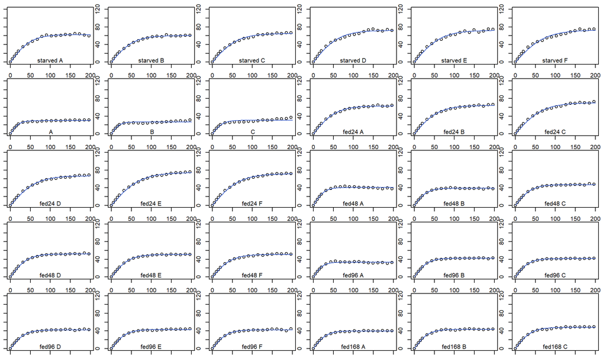

```r
fire$ID <- paste(fire$ShortTreat,fire$Rep)

pe.stats <- as.data.frame(unique(fire$ID))
names(pe.stats) <- 'ID'
#pe.stats$Prey <- fire$Prey[match(pe.stats$ID,fire$ID)]
#pe.stats$Fed <- fire$Fed[match(pe.stats$ID,fire$ID)]
#pe.stats$Rep <- fire$Rep[match(pe.stats$ID,fire$ID)]
#pe.stats$Day <- fire$Day[match(pe.stats$ID,fire$ID)]
pe.stats$Fv.Fm <- NA
pe.stats$Pmax <- NA
pe.stats$Pmax.err <- NA
pe.stats$Pmax.p <- NA
pe.stats$a <- NA
pe.stats$a.err <- NA
pe.stats$a.p <- NA

PARset <- seq(from =0, to = 200, length.out = 100)  # Create a holding vector of light levels to use for plotting later

for(i in 1:(dim(pe.stats)[1])){
    if((i-1)%%30 == 0){   # plot results in 30-panel figures
        par(mar=c(1,1,1,1),mfrow=c(5,6))
    }

    subdat <- fire[fire$ID==pe.stats$ID[i],]   # Subset the data


    plot(subdat$PAR, subdat$ETR,xlim=c(0,200),ylim=c(0,120)); text(max(PARset)*0.5,5,pe.stats$ID[i])  # Plot the raw data

    pe.stats$Fv.Fm[i] <- subdat[subdat$PAR==0,]$Fv.Fm # Save FvFm
    nls.summ <- summary(nls(ETR ~ P * tanh(a * PAR / P), data= subdat, start = list(P = 100, a = 1.415)))   # Do curve fit

    pe.stats$Pmax[i] <- nls.summ$p[1,1]   # Save various statistical parameters
    pe.stats$Pmax.err[i] <- nls.summ$p[1,2]
    pe.stats$Pmax.p[i] <- nls.summ$p[1,4]
    pe.stats$a[i] <- nls.summ$p[2,1]
    pe.stats$a.err[i] <- nls.summ$p[2,2]
    pe.stats$a.p[i] <- nls.summ$p[2,4]

    predictset <- pe.stats$Pmax[i]*tanh(pe.stats$a[i]*PARset/pe.stats$Pmax[i])
    lines(PARset,predictset, col='royalblue3')  # Overlay the curve fit
}
```

```r
pe.stats$Ek <- pe.stats$Pmax / pe.stats$a
pe.stats$P_I <- pe.stats$Pmax * tanh(pe.stats$a * 10 / pe.stats$Pmax)
pe.stats$P_I.C <- pe.stats$P_I* Cfix.mult
```

[figure not shown]

Just your normal run-of-the-mill PE curves.

## Timeseries data: Cell counts

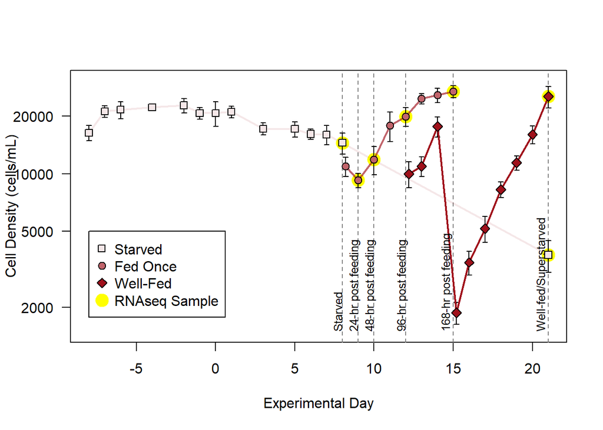

```r
plot(dat$Day,dat$CellCount,las=1,xlab='Experimental Day',ylab='Cell Density (cells/mL)',log='y',pch=c(21,22,23)[dat$Feeding],type='n') # I like to make the first plot using all the data, which automatically gets the y-axis limits wide enough to accommodate any error bars. The type='n' argument makes the points invisible, but alternatively we could make them a very light gray so you could "see" the real data

abline(v=c(8,9,10,12,15,21),lty=2,col='gray50') # Add vertical lines indicating sampling days

count.summ <- summarySE(data=dat,"CellCount",groupvars=c("Day","Feeding"),na.rm=TRUE) # Use summarySE function to create summary of the count data


count.summ$RNAseq <- c(rep(0,12),1,0,1,1,0,1,rep(0,5),1,rep(0,6),1,1)
points(count.summ$Day,count.summ$CellCount,pch=21,cex=2*count.summ$RNAseq,col='yellow',bg='yellow')

arrows(count.summ$Day,count.summ$CellCount+count.summ$sd,count.summ$Day,count.summ$CellCount-count.summ$sd,code=3,length=.03,angle=90) # Add error bars

count.summ.starved <- count.summ[count.summ$Feeding=='starved',]
lines(count.summ.starved$Day,count.summ.starved$CellCount,lwd=2,col=SM.N) # Add lines for each of the feeding treatments

count.summ.fed <- count.summ[count.summ$Feeding=='fed',]
lines(count.summ.fed$Day,count.summ.fed$CellCount,lwd=2,col=SM.48)

count.summ.wellfed <- count.summ[count.summ$Feeding=='wellfed',]
lines(count.summ.wellfed$Day,count.summ.wellfed$CellCount,lwd=2,col=SM.Y)

points(count.summ$Day,count.summ$CellCount,pch=c(21,22,23)[as.factor(count.summ$Feeding)],cex=1.2,bg ="white"); points(count.summ$Day,count.summ$CellCount,pch=c(21,22,23)[as.factor(count.summ$Feeding)],cex=1.2,bg = c(SM.48,SM.N,SM.Y)[as.factor(count.summ$Feeding)]) # First plot a white background, so that the transparency doesn't let other lines show through



legend(-8,5000,legend=c("Starved",'Fed Once','Well-Fed','RNAseq Sample'),pch=c(22,21,23,21),pt.cex=c(1.2,1.2,1.2,2),pt.bg=c(SM.N,SM.48,SM.Y,'yellow'),col=c(rep('black',3),'yellow'),bty='o',lty=c(0,0,0,0))

text(7.2,1500,"Starved",srt=90,cex=.8,pos=4)
text(8.2,1500,"24-hr post feeding",srt=90,cex=.8,pos=4)
text(9.2,1500,"48-hr post feeding",srt=90,cex=.8,pos=4)
text(11.2,1500,"96-hr post feeding",srt=90,cex=.8,pos=4)
text(14,1500,"168-hr post feeding",srt=90,cex=.8,pos=4)
text(20,1500,"Well-fed/Superstarved",srt=90,cex=.8,pos=4)
```

Cell densities over time. Light colors are the starvation timeseries: The cells were starving for a week before this timeseries starts (on Day -8; maybe I should adjust when the experimental day 0 is), so they hang on for another week before entering a slow decline. The very last point in this timeseries is on day 21; these are the “super-starved” cells who have been starving for 5 weeks! They hung on pretty well in spite of that; sadly I didn’t think to take population measurements over that whole timeseries as these were sort of “happy accident” samples.

The intermediate red timeseries shows the pulsed feeding experiment. The cells got fed 10 prey : 1 Mesodinium on day 8, and then I took timepoints 24, 48, 96, and 168h (7 days) post feeding. You can see that the cells actually experience some mortality in that first day of feeding. I fed them pretty dense prey, but had to feed a lot (because the culture was quite dense), so this could be some byproduct in the prey culture that they didn’t like? But after 24hrs, growth picks up, and you can see them continue that growth for about 5 days before plateauing.

Four days after the first feeding, I split off an aliquot of the culture to put into the “well-fed” treatment (shown in the darkest red). Every two days, I topped these cultures off with prey to a 5:1 ratio; the steep decline on Day 15 is a dilution to make sure that they could continue to grow exponentially. The well-fed timepoint was taken on Day 21, one day after their last feeding (so there were still prey present in the culture before washing for sampling).

## Timeseries data: Growth rates

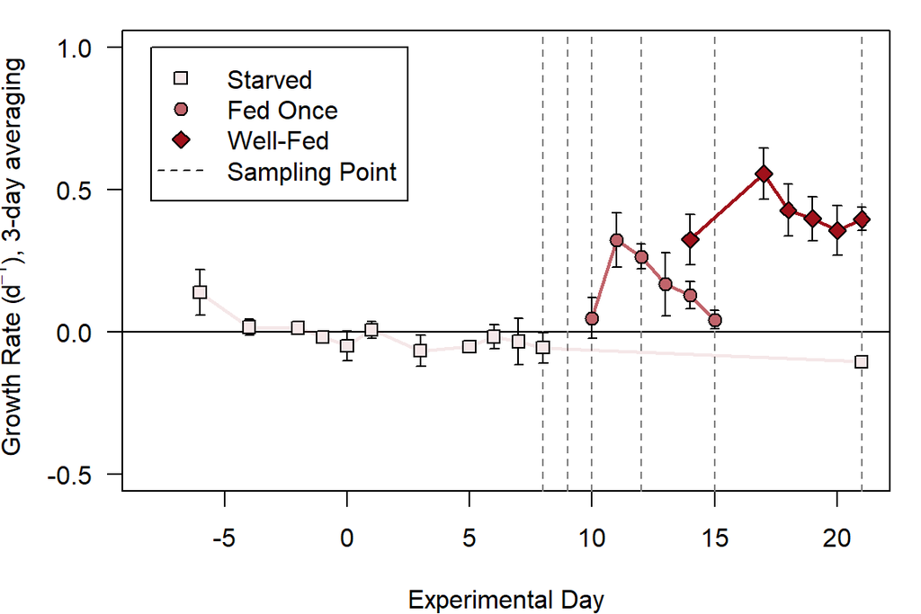

```r
dat$mu.3day.terminal <- NaN # growth curves with 3 day sliding window; growth rate is saved for the last day
dat$mu.3day.centered <- NaN # growth rates with 3 day sliding window; growth rate is saved for the central day

dat2 <- dat[order(dat$Feeding,dat$Rep,dat$Day),]


window <- 3 # number of datapoints needed to compute a growth rate
for(i in window:dim(dat2)[1]){ # If you start this for loop too early, there are insufficient data to calculate a growth rate
  if(dat2$ID[i]==dat2$ID[i-window+1]){ # Only calculate growth rates when the previous datapoints are from the same treatment group and flask
    lm1 <- lm(dat2[(i-window+1):i,]$logcells~dat2[(i-window+1):i,]$Day) # Compute a linear model to get the growth rate
    if(!is.na(lm1$coefficients[2])){ # If the linear model worked
      if(lm1$coefficients[2]>-.5){  # And if the slope is > -.5 (i.e., the cells weren't diluted)
        dat2$mu.3day.terminal[i] <- lm1$coefficients[2]  # save the slope as the terminal growth rate for the 3-day window
        dat2$mu.3day.centered[i-1] <- lm1$coefficients[2] }} # save the slope as the centered growth rate for the midpoint of this 3-day window
  }
}


par(mar=c(4,4,1,1))

# Plots with terminal growth rates
plot(dat2$Day,dat2$mu.3day.terminal,las=1,xlab='Experimental Day',ylab=expression(paste('Growth Rate (',d^{-1},'), 3-day averaging')),pch=c(21,22,23)[dat$Feeding],ylim=c(-.5,1),type='n')
abline(h=0,lty=1)
abline(v=c(8,9,10,12,15,21),lty=2,col='gray50') # Add vertical lines indicating sampling days

mu.summ <- summarySE(data=dat2[!is.na(dat2$mu.3day.terminal),],"mu.3day.terminal",groupvars=c("Day","Feeding"),na.rm=TRUE) # Use summarySE function to create summary of the growth data
#mu.summ[mu.summ$mu<-.5,]$mu <- NaN

arrows(mu.summ$Day,mu.summ$mu.3day.terminal+mu.summ$sd,mu.summ$Day,mu.summ$mu.3day.terminal-mu.summ$sd,code=3,length=.03,angle=90) # Add error bars

mu.summ.starved <- mu.summ[mu.summ$Feeding=='starved',]
lines(mu.summ.starved$Day,mu.summ.starved$mu.3day.terminal,lwd=2,col=SM.N) # Add lines for each of the feeding treatments

mu.summ.fed <- mu.summ[mu.summ$Feeding=='fed',]
lines(mu.summ.fed$Day,mu.summ.fed$mu.3day.terminal,lwd=2,col=SM.48)

mu.summ.wellfed <- mu.summ[mu.summ$Feeding=='wellfed',]
lines(mu.summ.wellfed$Day,mu.summ.wellfed$mu.3day.terminal,lwd=2,col=SM.Y)


points(mu.summ$Day,mu.summ$mu.3day.terminal,pch=c(21,22,23)[as.factor(mu.summ$Feeding)],cex=1.2,bg ="white"); points(mu.summ$Day,mu.summ$mu.3day.terminal,pch=c(21,22,23)[as.factor(mu.summ$Feeding)],cex=1.2,bg = c(SM.48,SM.N,SM.Y)[as.factor(mu.summ$Feeding)]) # First plot a white background, so that the transparency doesn't let other lines show through

legend(-8,1,legend=c("Starved",'Fed Once','Well-Fed','Sampling Point'),pch=c(22,21,23),pt.cex=c(1.2,1.2,1.2,0),pt.bg=c(SM.N,SM.48,SM.Y),bty='o',lty=c(0,0,0,2))
```

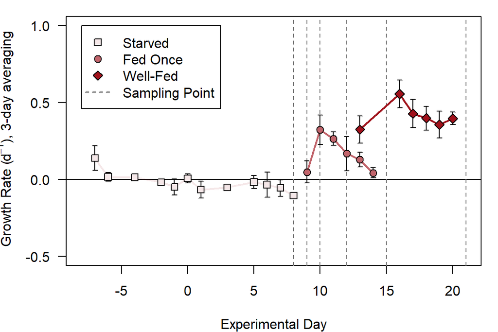

```r
# Plots with centered growth rates
plot(dat2$Day,dat2$mu.3day.centered,las=1,xlab='Experimental Day',ylab=expression(paste('Growth Rate (',d^{-1},'), 3-day averaging')),pch=c(21,22,23)[dat$Feeding],ylim=c(-.5,1),type='n')
abline(h=0,lty=1)
abline(v=c(8,9,10,12,15,21),lty=2,col='gray50') # Add vertical lines indicating sampling days

mu.summ <- summarySE(data=dat2[!is.na(dat2$mu.3day.centered),],"mu.3day.centered",groupvars=c("Day","Feeding"),na.rm=TRUE) # Use summarySE function to create summary of the growth data
#mu.summ[mu.summ$mu<-.5,]$mu <- NaN

arrows(mu.summ$Day,mu.summ$mu.3day.centered+mu.summ$sd,mu.summ$Day,mu.summ$mu.3day.centered-mu.summ$sd,code=3,length=.03,angle=90) # Add error bars

mu.summ.starved <- mu.summ[mu.summ$Feeding=='starved',]
lines(mu.summ.starved$Day,mu.summ.starved$mu.3day.centered,lwd=2,col=SM.N) # Add lines for each of the feeding treatments

mu.summ.fed <- mu.summ[mu.summ$Feeding=='fed',]
lines(mu.summ.fed$Day,mu.summ.fed$mu.3day.centered,lwd=2,col=SM.48)

mu.summ.wellfed <- mu.summ[mu.summ$Feeding=='wellfed',]
lines(mu.summ.wellfed$Day,mu.summ.wellfed$mu.3day.centered,lwd=2,col=SM.Y)


points(mu.summ$Day,mu.summ$mu.3day.centered,pch=c(21,22,23)[as.factor(mu.summ$Feeding)],cex=1.2,bg ="white"); points(mu.summ$Day,mu.summ$mu.3day.centered,pch=c(21,22,23)[as.factor(mu.summ$Feeding)],cex=1.2,bg = c(SM.48,SM.N,SM.Y)[as.factor(mu.summ$Feeding)]) # First plot a white background, so that the transparency doesn't let other lines show through

legend(-8,1,legend=c("Starved",'Fed Once','Well-Fed','Sampling Point'),pch=c(22,21,23),pt.cex=c(1.2,1.2,1.2,0),pt.bg=c(SM.N,SM.48,SM.Y),bty='o',lty=c(0,0,0,2))
```

This graph is another way of visualizing the timeseries above, presenting growth rates over time. This allows us to more clearly see how the pulse-fed cells have an increase, then decrease in their growth rate. It also reveals that the well-fed cells’ growth rates do slow down a bit once they get into the rhythm of the feeding. Unclear if this is just noise, but a growth rate of 0.5 is about as strong as I’ve seen them at this light level (10uE).

Stacking population size, growth rates, and cryptophyte : MC ratios in the same plot

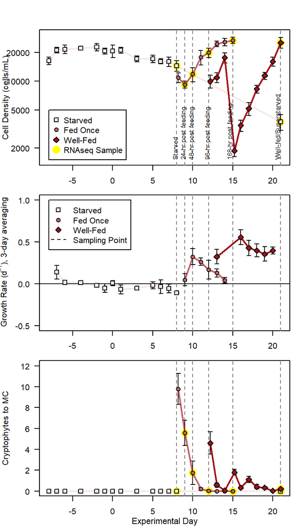

```r
par(mar = c(1,4,3,1), mfrow=c(3,1))

# MC population size
plot(dat$Day,dat$CellCount,las=1,xlab='Experimental Day',ylab='Cell Density (cells/mL)',log='y',pch=c(21,22,23)[dat$Feeding],type='n') # I like to make the first plot using all the data, which automatically gets the y-axis limits wide enough to accommodate any error bars. The type='n' argument makes the points invisible, but alternatively we could make them a very light gray so you could "see" the real data

abline(v=c(8,9,10,12,15,21),lty=2,col='gray50') # Add vertical lines indicating sampling days

count.summ <- summarySE(data=dat,"CellCount",groupvars=c("Day","Feeding"),na.rm=TRUE) # Use summarySE function to create summary of the count data


count.summ$RNAseq <- c(rep(0,12),1,0,1,1,0,1,rep(0,5),1,rep(0,6),1,1)
points(count.summ$Day,count.summ$CellCount,pch=21,cex=2*count.summ$RNAseq,col='yellow',bg='yellow')

arrows(count.summ$Day,count.summ$CellCount+count.summ$sd,count.summ$Day,count.summ$CellCount-count.summ$sd,code=3,length=.03,angle=90) # Add error bars

count.summ.starved <- count.summ[count.summ$Feeding=='starved',]
lines(count.summ.starved$Day,count.summ.starved$CellCount,lwd=2,col=SM.N) # Add lines for each of the feeding treatments

count.summ.fed <- count.summ[count.summ$Feeding=='fed',]
lines(count.summ.fed$Day,count.summ.fed$CellCount,lwd=2,col=SM.48)

count.summ.wellfed <- count.summ[count.summ$Feeding=='wellfed',]
lines(count.summ.wellfed$Day,count.summ.wellfed$CellCount,lwd=2,col=SM.Y)

points(count.summ$Day,count.summ$CellCount,pch=c(21,22,23)[as.factor(count.summ$Feeding)],cex=1.2,bg ="white"); points(count.summ$Day,count.summ$CellCount,pch=c(21,22,23)[as.factor(count.summ$Feeding)],cex=1.2,bg = c(SM.48,SM.N,SM.Y)[as.factor(count.summ$Feeding)]) # First plot a white background, so that the transparency doesn't let other lines show through

legend(-8,5000,legend=c("Starved",'Fed Once','Well-Fed','RNAseq Sample'),pch=c(22,21,23,21),pt.cex=c(1.2,1.2,1.2,2),pt.bg=c(SM.N,SM.48,SM.Y,'yellow'),col=c(rep('black',3),'yellow'),bty='o',lty=c(0,0,0,0))

text(7.2,1500,"Starved",srt=90,cex=.8,pos=4)
text(8.2,1500,"24-hr post feeding",srt=90,cex=.8,pos=4)
text(9.2,1500,"48-hr post feeding",srt=90,cex=.8,pos=4)
text(11.2,1500,"96-hr post feeding",srt=90,cex=.8,pos=4)
text(14,1500,"168-hr post feeding",srt=90,cex=.8,pos=4)
text(20,1500,"Well-fed/Superstarved",srt=90,cex=.8,pos=4)


par(mar=c(2,4,2,1))
# Growth rates
plot(dat2$Day,dat2$mu.3day.centered,las=1,xlab='Experimental Day',ylab=expression(paste('Growth Rate (',d^{-1},'), 3-day averaging')),pch=c(21,22,23)[dat$Feeding],ylim=c(-.5,1),type='n')
abline(h=0,lty=1)
abline(v=c(8,9,10,12,15,21),lty=2,col='gray50') # Add vertical lines indicating sampling days

mu.summ <- summarySE(data=dat2[!is.na(dat2$mu.3day.centered),],"mu.3day.centered",groupvars=c("Day","Feeding"),na.rm=TRUE) # Use summarySE function to create summary of the growth data
#mu.summ[mu.summ$mu<-.5,]$mu <- NaN

arrows(mu.summ$Day,mu.summ$mu.3day.centered+mu.summ$sd,mu.summ$Day,mu.summ$mu.3day.centered-mu.summ$sd,code=3,length=.03,angle=90) # Add error bars

mu.summ.starved <- mu.summ[mu.summ$Feeding=='starved',]
lines(mu.summ.starved$Day,mu.summ.starved$mu.3day.centered,lwd=2,col=SM.N) # Add lines for each of the feeding treatments

mu.summ.fed <- mu.summ[mu.summ$Feeding=='fed',]
lines(mu.summ.fed$Day,mu.summ.fed$mu.3day.centered,lwd=2,col=SM.48)

mu.summ.wellfed <- mu.summ[mu.summ$Feeding=='wellfed',]
lines(mu.summ.wellfed$Day,mu.summ.wellfed$mu.3day.centered,lwd=2,col=SM.Y)


points(mu.summ$Day,mu.summ$mu.3day.centered,pch=c(21,22,23)[as.factor(mu.summ$Feeding)],cex=1.2,bg ="white"); points(mu.summ$Day,mu.summ$mu.3day.centered,pch=c(21,22,23)[as.factor(mu.summ$Feeding)],cex=1.2,bg = c(SM.48,SM.N,SM.Y)[as.factor(mu.summ$Feeding)]) # First plot a white background, so that the transparency doesn't let other lines show through

legend(-8,1,legend=c("Starved",'Fed Once','Well-Fed','Sampling Point'),pch=c(22,21,23),pt.cex=c(1.2,1.2,1.2,0),pt.bg=c(SM.N,SM.48,SM.Y),bty='o',lty=c(0,0,0,2))



par(mar=c(3,4,1,1))
# Cryptophyte to MC ratio
dat$Crypto.to.MC <- dat$CryptoCount / dat$CellCount
plot(dat$Day,dat$Crypto.to.MC,las=1,xlab='Experimental Day',ylab='Cryptophytes to MC',pch=c(21,22,23)[dat$Feeding],type='n') # I like to make the first plot using all the data, which automatically gets the y-axis limits wide enough to accommodate any error bars. The type='n' argument makes the points invisible, but alternatively we could make them a very light gray so you could "see" the real data
mtext('Experimental Day',side=1,line=2,cex=.7)

abline(v=c(8,9,10,12,15,21),lty=2,col='gray50') # Add vertical lines indicating sampling days

ratio.summ <- summarySE(data=dat,"Crypto.to.MC",groupvars=c("Day","Feeding"),na.rm=TRUE) # Use summarySE function to create summary of the count data


ratio.summ$RNAseq <- c(rep(0,12),1,0,1,1,0,1,rep(0,5),1,rep(0,6),1,1)
points(ratio.summ$Day,ratio.summ$Crypto.to.MC,pch=21,cex=2*ratio.summ$RNAseq,col='yellow',bg='yellow')

arrows(ratio.summ$Day,ratio.summ$Crypto.to.MC+ratio.summ$sd,ratio.summ$Day,ratio.summ$Crypto.to.MC-ratio.summ$sd,code=3,length=.03,angle=90) # Add error bars

ratio.summ.starved <- ratio.summ[ratio.summ$Feeding=='starved',]
lines(ratio.summ.starved$Day,ratio.summ.starved$Crypto.to.MC,lwd=2,col=SM.N) # Add lines for each of the feeding treatments

ratio.summ.fed <- ratio.summ[ratio.summ$Feeding=='fed',]
lines(ratio.summ.fed$Day,ratio.summ.fed$Crypto.to.MC,lwd=2,col=SM.48)

ratio.summ.wellfed <- ratio.summ[ratio.summ$Feeding=='wellfed',]
lines(ratio.summ.wellfed$Day,ratio.summ.wellfed$Crypto.to.MC,lwd=2,col=SM.Y)

points(ratio.summ$Day,ratio.summ$Crypto.to.MC,pch=c(21,22,23)[as.factor(ratio.summ$Feeding)],cex=1.2,bg ="white"); points(ratio.summ$Day,ratio.summ$Crypto.to.MC,pch=c(21,22,23)[as.factor(ratio.summ$Feeding)],cex=1.2,bg = c(SM.48,SM.N,SM.Y)[as.factor(ratio.summ$Feeding)]) # First plot a white background, so that the transparency doesn't let other lines show through
```

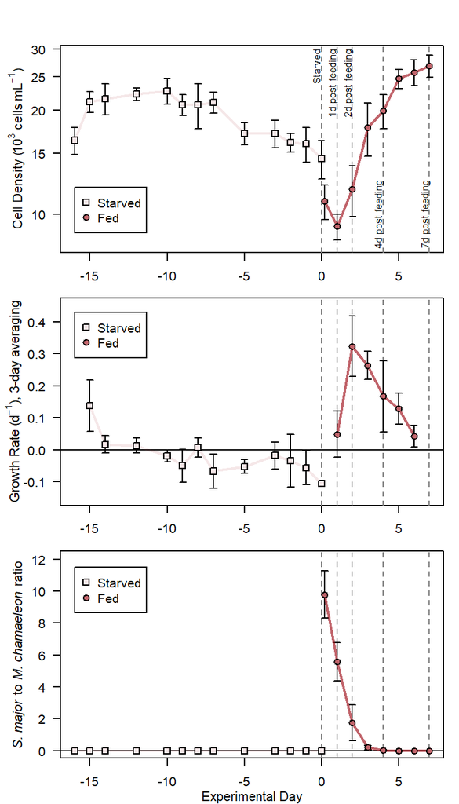

```r
dat.crop <- dat[dat$Feeding!='wellfed' & dat$Day < 21,]
dat.crop$Day.corr <- dat.crop$Day-8
par(mar = c(1,4,3,1), mfrow=c(3,1))

# MC population size
plot(dat.crop$Day.corr,dat.crop$CellCount/1000,las=1,xlab='Experimental Day',ylab='',log='y',pch=c(21,22,23)[dat.crop$Feeding],type='n')
mtext(expression(paste('Cell Density (',10^3,' cells ',mL^-1,')')),side=2,line=2.2,cex=.7)
# I like to make the first plot using all the data, which automatically gets the y-axis limits wide enough to accommodate any error bars. The type='n' argument makes the points invisible, but alternatively we could make them a very light gray so you could "see" the real data

abline(v=c(8,9,10,12,15,21)-8,lty=2,col='gray50') # Add vertical lines indicating sampling days

count.summ <- summarySE(data=dat.crop,"CellCount",groupvars=c("Day.corr","Feeding"),na.rm=TRUE) # Use summarySE function to create summary of the count data
count.summ$RNAseq <- c(rep(0,12),1,0,1,1,0,1,rep(0,3))

# Error bars
arrows(count.summ$Day,count.summ$CellCount/1000+count.summ$sd/1000,count.summ$Day,count.summ$CellCount/1000-count.summ$sd/1000,code=3,length=.03,angle=90) # Add error bars

# Lines
count.summ.starved <- count.summ[count.summ$Feeding=='starved',]
lines(count.summ.starved$Day,count.summ.starved$CellCount/1000,lwd=2,col=SM.N) # Add lines for each of the feeding treatments
count.summ.fed <- count.summ[count.summ$Feeding=='fed',]
lines(count.summ.fed$Day,count.summ.fed$CellCount/1000,lwd=2,col=SM.48)

# Points
points(count.summ$Day,count.summ$CellCount/1000,pch=c(21,22,23)[as.factor(count.summ$Feeding)],cex=1.2,bg ="white"); points(count.summ$Day,count.summ$CellCount/1000,pch=c(21,22,23)[as.factor(count.summ$Feeding)],cex=1.2,bg = c(SM.48,SM.N,SM.Y)[as.factor(count.summ$Feeding)]) # First plot a white background, so that the transparency doesn't let other lines show through

legend(-16,12,legend=c("Starved",'Fed'),pch=c(22,21,23,21),pt.cex=c(1.2,1.2,1.2,2),pt.bg=c(SM.N,SM.48,SM.Y,'yellow'),col=c(rep('black',3),'yellow'),bty='o',lty=c(0,0,0,0))

text(.2,30,"Starved",srt=90,cex=.8,pos=2)
text(1.2,30,"1d post feeding",srt=90,cex=.8,pos=2)
text(2.2,30,"2d post feeding",srt=90,cex=.8,pos=2)
text(3.2,8,"4d post feeding",srt=90,cex=.8,pos=4)
text(6.2,8,"7d post feeding",srt=90,cex=.8,pos=4)
#text(20,1500,"Well-fed/Superstarved",srt=90,cex=.8,pos=4)


# Growth rates
par(mar=c(2,4,2,1))
dat2.crop <- dat2[dat2$Feeding!='wellfed',]
dat2.crop$Day.corr <- dat2.crop$Day-8
# Growth rates
plot(dat2.crop$Day.corr,dat2.crop$mu.3day.centered,las=1,xlab='Experimental Day',ylab='',pch=c(21,22,23)[dat2.crop$Feeding],ylim=c(-.15,0.45),xlim=c(-16,7),type='n')
mtext(expression(paste('Growth Rate (',d^{-1},'), 3-day averaging')),side=2,line=2.4,cex=.7)
abline(h=0,lty=1)
abline(v=c(8,9,10,12,15,21)-8,lty=2,col='gray50') # Add vertical lines indicating sampling days

mu.summ <- summarySE(data=dat2.crop[!is.na(dat2.crop$mu.3day.centered),],"mu.3day.centered",groupvars=c("Day.corr","Feeding"),na.rm=TRUE) # Use summarySE function to create summary of the growth data
#mu.summ[mu.summ$mu<-.5,]$mu <- NaN

arrows(mu.summ$Day.corr,mu.summ$mu.3day.centered+mu.summ$sd,mu.summ$Day.corr,mu.summ$mu.3day.centered-mu.summ$sd,code=3,length=.03,angle=90) # Add error bars

mu.summ.starved <- mu.summ[mu.summ$Feeding=='starved',]
lines(mu.summ.starved$Day.corr,mu.summ.starved$mu.3day.centered,lwd=2,col=SM.N) # Add lines for each of the feeding treatments

mu.summ.fed <- mu.summ[mu.summ$Feeding=='fed',]
lines(mu.summ.fed$Day.corr,mu.summ.fed$mu.3day.centered,lwd=2,col=SM.48)

points(mu.summ$Day.corr,mu.summ$mu.3day.centered,pch=c(21,22,23)[as.factor(mu.summ$Feeding)],cex=1.2,bg ="white"); points(mu.summ$Day.corr,mu.summ$mu.3day.centered,pch=c(21,22,23)[as.factor(mu.summ$Feeding)],cex=1.2,bg = c(SM.48,SM.N,SM.Y)[as.factor(mu.summ$Feeding)]) # First plot a white background, so that the transparency doesn't let other lines show through

legend(-16,.43,legend=c("Starved",'Fed'),pch=c(22,21,23,21),pt.cex=c(1.2,1.2,1.2,2),pt.bg=c(SM.N,SM.48,SM.Y,'yellow'),col=c(rep('black',3),'yellow'),bty='o',lty=c(0,0,0,0))



par(mar=c(3,4,1,1))
# Cryptophyte to MC ratio
dat$Crypto.to.MC <- dat$CryptoCount / dat$CellCount
dat.crop$Crypto.to.MC <- dat.crop$CryptoCount / dat.crop$CellCount
plot(dat.crop$Day.corr,dat.crop$Crypto.to.MC,las=1,xlab='Experimental Day',ylab='',pch=c(21,22,23)[dat$Feeding],type='n')
mtext(expression(paste(italic('S. major'),' to ',italic('M. chamaeleon'),' ratio')),side=2,line=2.2,cex=.7)
mtext('Experimental Day',side=1,line=2,cex=.7)
abline(h=0,lty=1)
abline(v=c(8,9,10,12,15,21)-8,lty=2,col='gray50') # Add vertical lines indicating sampling days

ratio.summ <- summarySE(data=dat.crop,"Crypto.to.MC",groupvars=c("Day.corr","Feeding"),na.rm=TRUE) # Use summarySE function to create summary of the count data

arrows(ratio.summ$Day.corr,ratio.summ$Crypto.to.MC+ratio.summ$sd,ratio.summ$Day.corr,ratio.summ$Crypto.to.MC-ratio.summ$sd,code=3,length=.03,angle=90) # Add error bars

ratio.summ.starved <- ratio.summ[ratio.summ$Feeding=='starved',]
lines(ratio.summ.starved$Day.corr,ratio.summ.starved$Crypto.to.MC,lwd=2,col=SM.N) # Add lines for each of the feeding treatments

ratio.summ.fed <- ratio.summ[ratio.summ$Feeding=='fed',]
lines(ratio.summ.fed$Day.corr,ratio.summ.fed$Crypto.to.MC,lwd=2,col=SM.48)

points(ratio.summ$Day.corr,ratio.summ$Crypto.to.MC,pch=c(21,22,23)[as.factor(ratio.summ$Feeding)],cex=1.2,bg ="white"); points(ratio.summ$Day.corr,ratio.summ$Crypto.to.MC,pch=c(21,22,23)[as.factor(ratio.summ$Feeding)],cex=1.2,bg = c(SM.48,SM.N,SM.Y)[as.factor(ratio.summ$Feeding)]) # First plot a white background, so that the transparency doesn't let other lines show through

legend(-16,11.5,legend=c("Starved",'Fed'),pch=c(22,21,23,21),pt.cex=c(1.2,1.2,1.2,2),pt.bg=c(SM.N,SM.48,SM.Y,'yellow'),col=c(rep('black',3),'yellow'),bty='o',lty=c(0,0,0,0))
```

## Photophysiology data

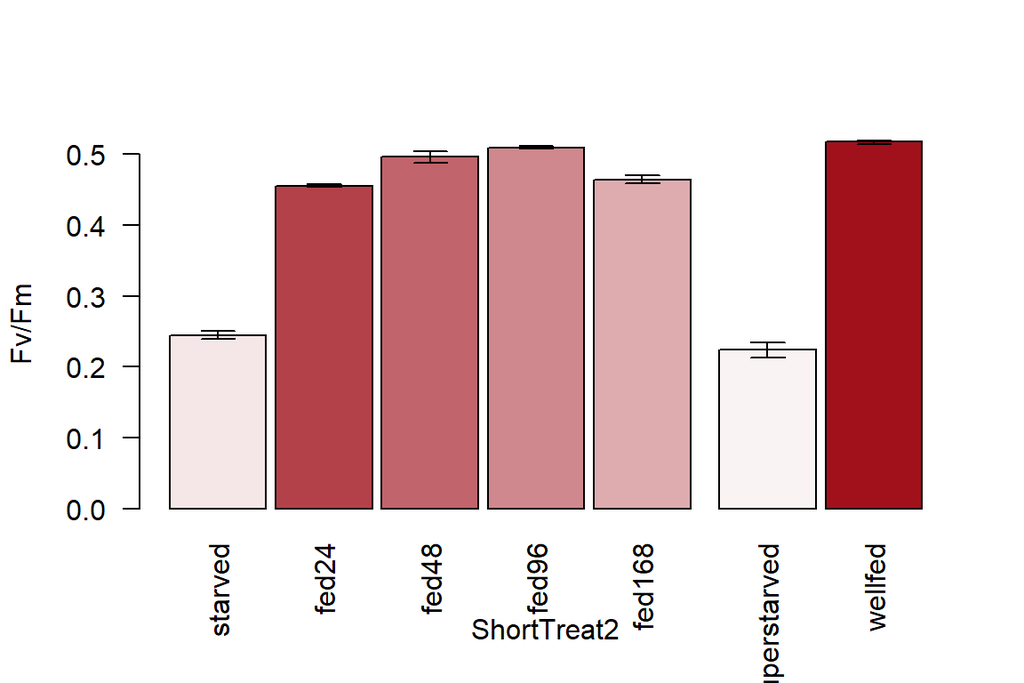

```r
dat$P_I.cell <- dat$P_I.C * dat$ChlpCell # pg C fixed per cell per hr

#dat$P_I.CtoC <- dat$P_I.cell/dat$C.p.cell/1000*12 # g C fixed per g C in a cell per day (note 12-hr light:dark cycle)

subdat <- droplevels(dat[!is.na(dat$P_I.cell),])

xcoords <- c(1,2,3,4,5,6.5,7.5)
spacing <- c(rep(.1,5),.3,.1)


bargraph.CI(ShortTreat2,Fv.Fm,data=subdat,space=spacing,las=2,col=colvec,ylab='Fv/Fm')
```

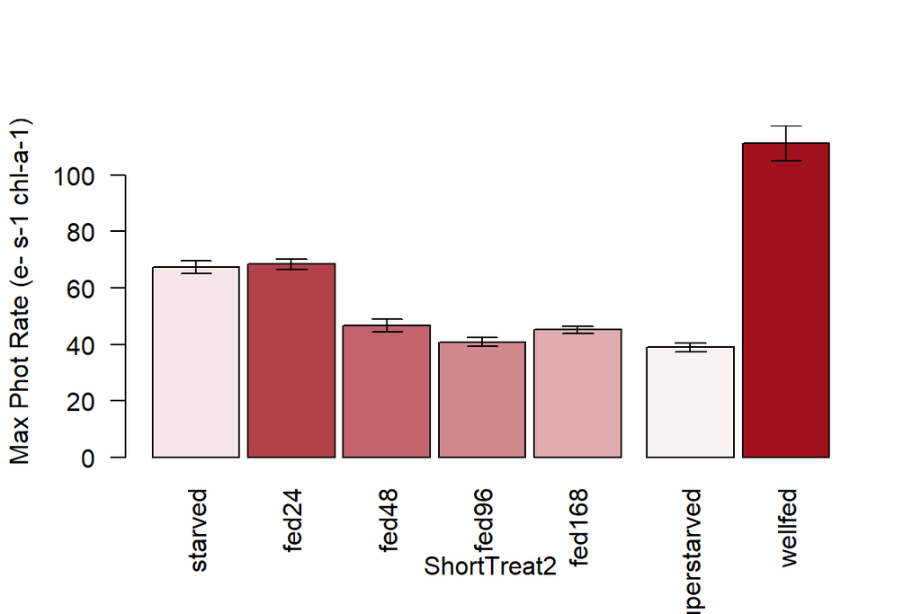

```r
bargraph.CI(ShortTreat2,Pmax,data=subdat,space=spacing,las=2,col=colvec,ylab='Max Phot Rate (e- s-1 chl-a-1)')
```

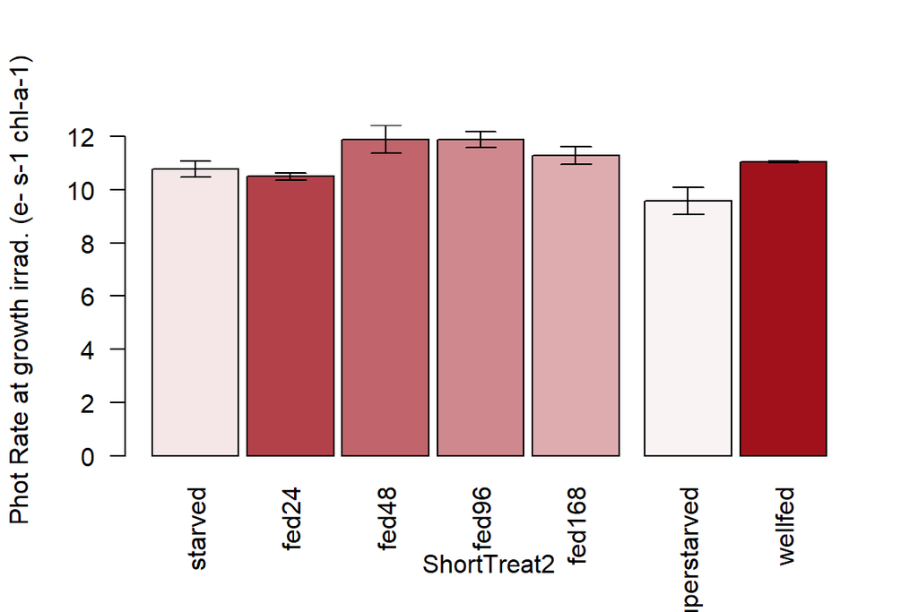

```r
bargraph.CI(ShortTreat2,P_I,data=subdat,space=spacing,las=2,col=colvec,ylab='Phot Rate at growth irrad. (e- s-1 chl-a-1)')
```

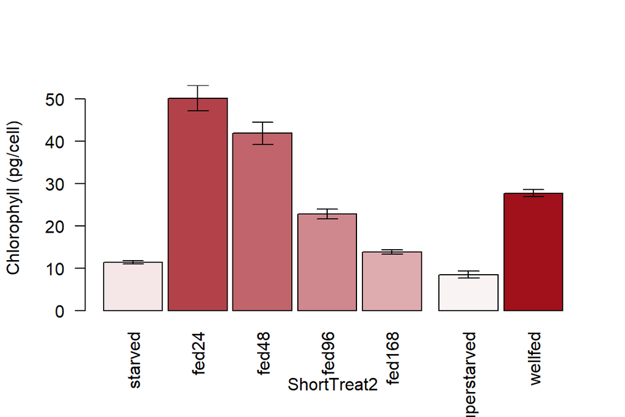

```r
bargraph.CI(ShortTreat2,ChlpCell,data=subdat,space=spacing,las=2,col=colvec,ylab='Chlorophyll (pg/cell)')
```

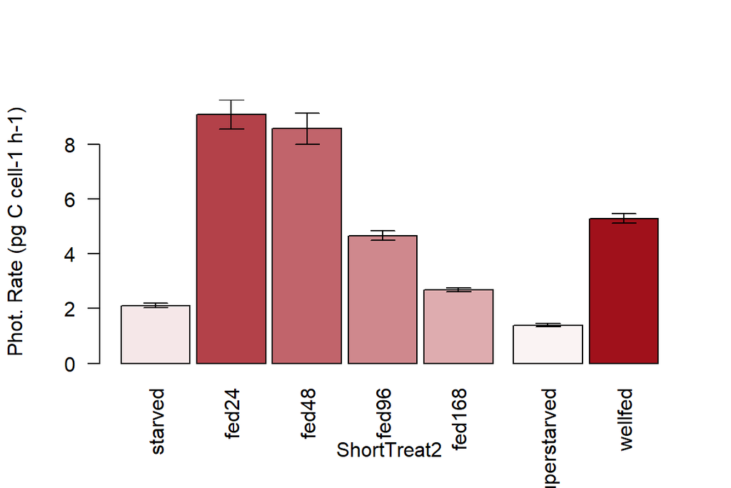

```r
bargraph.CI(ShortTreat2,P_I.cell,data=subdat,space=spacing,las=2,col=colvec,ylab='Phot. Rate (pg C cell-1 h-1)')
```

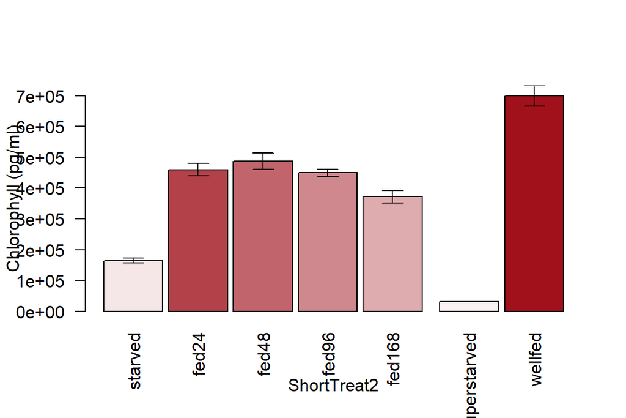

```r
bargraph.CI(ShortTreat2,ChlpmL,data=subdat,space=spacing,las=2,col=colvec,ylab='Chlorophyll (pg/ml)')
```

Here’s a blast of all the photophysiology data. I think the main story here is that when pulse-fed, M. chamaeleon gets back into the business of photosynthesis very quickly, but just getting a handful of plastids isn’t enough to sustain it for very long.

If you’re wondering why the per-cell chlorophyll content and carbon fixation rates of well-fed cells are less than those that have only had prey for a day or two, my guess is that this will come down to differences in cell size. I think the well-fed cells are probably slightly smaller, so they have a lower chlorophyll content and also an overall lower per-cell photosynthetic rate. (I took samples for CN analysis, so we’ll have data on cellular carbon content eventually.)

The secondary story (which we sort of already knew) is how damned long these guys can hang onto their plastids for. The starved samples had been starved for 3 weeks, and I’m frankly shocked that they retained so much photosynthetic capacity on a per-chlorophyll basis. The “superstarved” treatment (which went hungry for an additional two weeks) look more like what an extremely starved culture ought to be, in my opinion. But note that they haven’t given up the ghost of photosynthesis yet. ADDL NOTE 25 SEPT 2024: After working on these bugs at EMBL in May of this year, I am more convinced than ever that M. chamaeleon “holds on” to photosynthesis for a remarkably long time. Starved cells still had at least one relic plastid, typically with a large and very diffuse nucleus. This plastid was often very oddly shaped, and sometimes “spiraled” around the cell.

I’ll also note anecdotally that the cultures changed colour quite a bit during the experiment. Starved treatments were always straw-coloured, and 7-days post feeding, the pulse-fed treatments were yellowing back up too.

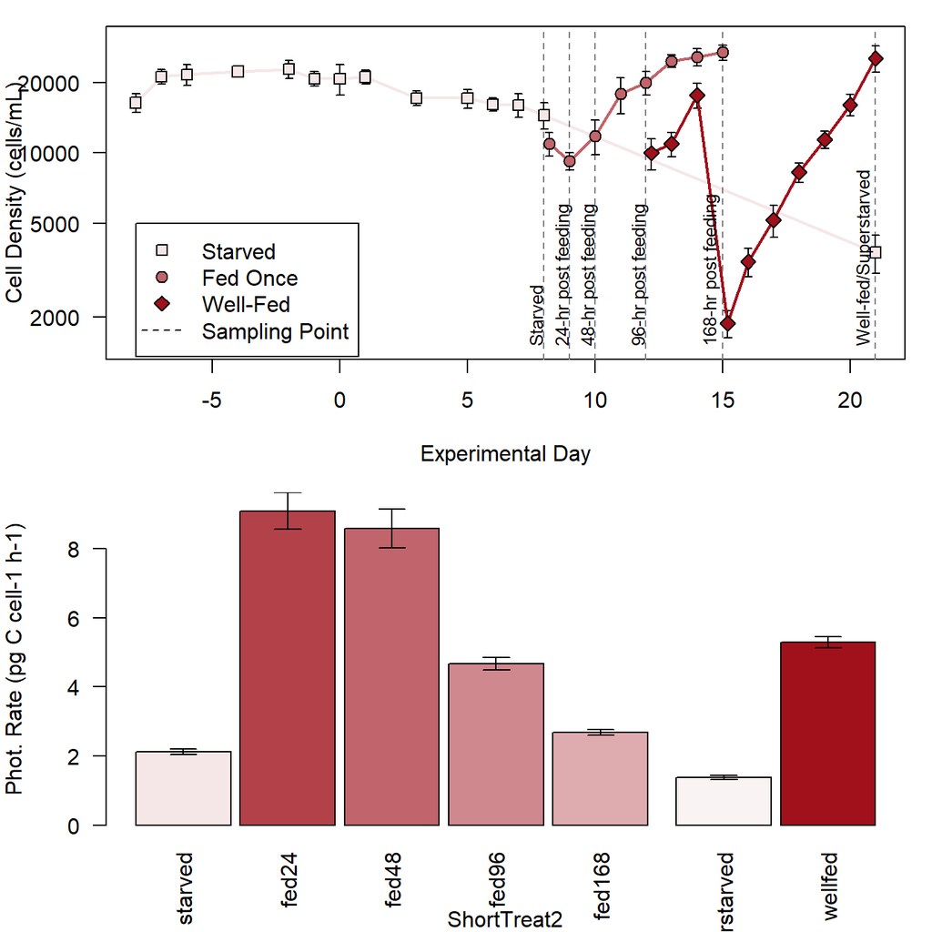

```r
par(mar=c(4,4,1,1),mfrow=c(2,1))
plot(dat$Day,dat$CellCount,las=1,xlab='Experimental Day',ylab='Cell Density (cells/mL)',log='y',pch=c(21,22,23)[dat$Feeding],type='n') # I like to make the first plot using all the data, which automatically gets the y-axis limits wide enough to accommodate any error bars. The type='n' argument makes the points invisible, but alternatively we could make them a very light gray so you could "see" the real data

abline(v=c(8,9,10,12,15,21),lty=2,col='gray50') # Add vertical lines indicating sampling days

count.summ <- summarySE(data=dat,"CellCount",groupvars=c("Day","Feeding"),na.rm=TRUE) # Use summarySE function to create summary of the count data

arrows(count.summ$Day,count.summ$CellCount+count.summ$sd,count.summ$Day,count.summ$CellCount-count.summ$sd,code=3,length=.03,angle=90) # Add error bars

count.summ.starved <- count.summ[count.summ$Feeding=='starved',]
lines(count.summ.starved$Day,count.summ.starved$CellCount,lwd=2,col=SM.N) # Add lines for each of the feeding treatments

count.summ.fed <- count.summ[count.summ$Feeding=='fed',]
lines(count.summ.fed$Day,count.summ.fed$CellCount,lwd=2,col=SM.48)

count.summ.wellfed <- count.summ[count.summ$Feeding=='wellfed',]
lines(count.summ.wellfed$Day,count.summ.wellfed$CellCount,lwd=2,col=SM.Y)


points(count.summ$Day,count.summ$CellCount,pch=c(21,22,23)[as.factor(count.summ$Feeding)],cex=1.2,bg ="white"); points(count.summ$Day,count.summ$CellCount,pch=c(21,22,23)[as.factor(count.summ$Feeding)],cex=1.2,bg = c(SM.48,SM.N,SM.Y)[as.factor(count.summ$Feeding)]) # First plot a white background, so that the transparency doesn't let other lines show through


legend(-8,5000,legend=c("Starved",'Fed Once','Well-Fed','Sampling Point'),pch=c(22,21,23),pt.cex=c(1.2,1.2,1.2,0),pt.bg=c(SM.N,SM.48,SM.Y),bty='o',lty=c(0,0,0,2))

text(7.2,1500,"Starved",srt=90,cex=.8,pos=4)
text(8.2,1500,"24-hr post feeding",srt=90,cex=.8,pos=4)
text(9.2,1500,"48-hr post feeding",srt=90,cex=.8,pos=4)
text(11.2,1500,"96-hr post feeding",srt=90,cex=.8,pos=4)
text(14,1500,"168-hr post feeding",srt=90,cex=.8,pos=4)
text(20,1500,"Well-fed/Superstarved",srt=90,cex=.8,pos=4)


bargraph.CI(ShortTreat2,P_I.cell,data=subdat,space=spacing,las=2,col=colvec,ylab='Phot. Rate (pg C cell-1 h-1)')
```

# Mapping growth rate data onto photosynthesis data

```r
subdat <- droplevels(dat[!is.na(dat$P_I.cell),])
head(subdat)
```

```
##    Expt Sample                        Species TreatNum Light
## 73    3     NA M chamaeleon NRMC1802 (fed SM)       NA    10
## 74    3     NA M chamaeleon NRMC1802 (fed SM)       NA    10
## 75    3     NA M chamaeleon NRMC1802 (fed SM)       NA    10
## 76    3     NA M chamaeleon NRMC1802 (fed SM)       NA    10
## 77    3     NA M chamaeleon NRMC1802 (fed SM)       NA    10
## 78    3     NA M chamaeleon NRMC1802 (fed SM)       NA    10
##               Treatment ShortTreat Feeding Rep Day CellCount ChlpCell Fv.Fm
## 73 10uE, light, starved    starved starved   A   8   17600.0  10.6023 0.221
## 74 10uE, light, starved    starved starved   B   8   15000.0  12.2324 0.257
## 75 10uE, light, starved    starved starved   C   8   14583.3   9.9802 0.247
## 76 10uE, light, starved    starved starved   D   8   13833.3  10.9182 0.246
## 77 10uE, light, starved    starved starved   E   8   13916.7  12.4161 0.245
## 78 10uE, light, starved    starved starved   F   8   12000.0  12.0743 0.253
##        Pmax  Pmax.err   Pmax.p         a      a.err      a.p       Ek       P_I
```

[output cut: 20 more lines]

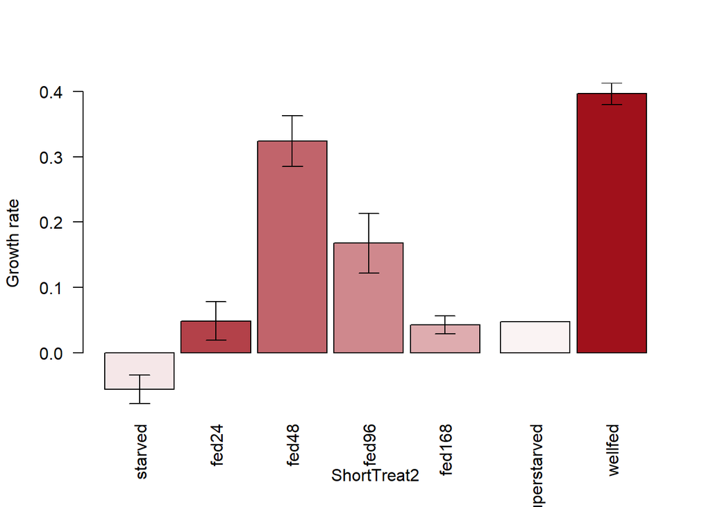

```r
for(i in 1:dim(subdat)[1]){
  if(subdat$ShortTreat[i]=='starved'){
    subdat$mu[i] <- dat2[dat2$Day==8 & dat2$Rep==subdat$Rep[i],]$mu.3day.terminal
  }
  if(subdat$ShortTreat[i] == 'fed48'){
    subdat$mu[i] <- dat2[dat2$Day==10 & dat2$Rep==subdat$Rep[i],]$mu.3day.centered
  }
  if(subdat$ShortTreat[i] == 'fed96'){
    subdat$mu[i] <- dat2[dat2$Day==12 & dat2$Rep==subdat$Rep[i],]$mu.3day.centered
  }
  if(subdat$ShortTreat[i] == 'fed168'){
    subdat$mu[i] <- dat2[dat2$Day==15 & dat2$Rep==subdat$Rep[i],]$mu.3day.terminal
  }
  if(subdat$ShortTreat[i] == 'wellfed'){
    subdat$mu[i] <- dat2[dat2$Day==21 & dat2$ShortTreat=='wellfed' & dat2$Rep==subdat$Rep[i],]$mu.3day.terminal
  }
  if(subdat$ShortTreat[i] == 'fed24'){
    subdat$mu[i] <- dat2[dat2$Day==9 & dat2$Rep==subdat$Rep[i],]$mu.3day.centered
  }
}


bargraph.CI(ShortTreat2,mu,data=subdat,space=spacing,las=2,col=colvec,ylab='Growth rate')
```

```r
#### write.csv(subdat,"/Users/hollyvm/GoogleSync/Mesodinium/JGI/Mchamaeleon_Starvation/physiol_growth_export.csv")
```

## Modified transcriptomic linkage testing different curve fits

```r
# Match the treatment variables
level.matching <- as.data.frame(levels(as.factor(subdat$ShortTreat)))
colnames(level.matching) <- 'ShortTreat'
level.matching$TreatmentDays <- c(7,1,2,4,0,50,NaN)
subdat$TreatmentDays <- level.matching$TreatmentDays[match(subdat$ShortTreat,level.matching$ShortTreat)]


# Form data summaries
PIcell.summ <- summarySE(data = subdat[subdat$ShortTreat!='superstarved' & subdat$ShortTreat!='wellfed' ,], 'P_I.cell', groupvars = 'TreatmentDays')
FvFm.summ <- summarySE(data = subdat[subdat$ShortTreat!='superstarved'& subdat$ShortTreat!='wellfed',], 'Fv.Fm', groupvars = 'TreatmentDays')
ChlpCell.summ <- summarySE(data = subdat[subdat$ShortTreat!='superstarved'& subdat$ShortTreat!='wellfed',], 'ChlpCell', groupvars = 'TreatmentDays')
mu.summ <- summarySE(data = subdat[subdat$ShortTreat!='superstarved'& subdat$ShortTreat!='wellfed',], 'mu', groupvars = 'TreatmentDays')


subcats <- unique(transcriptprop$desc)
```

Illustration of one category

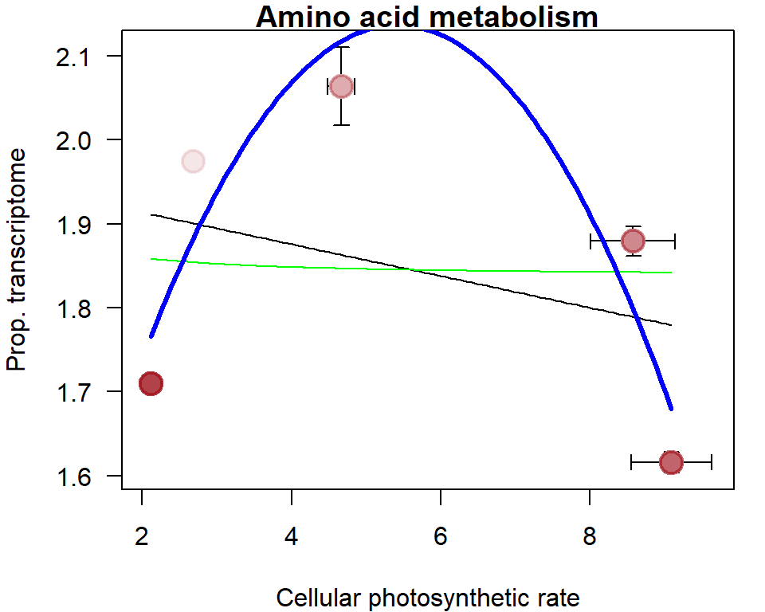

```r
i <- 5

par(mar=c(4,4,1,1))

# Summarize the transcriptional data
MCtranscr.summ <- summarySE(data = transcriptprop[transcriptprop$desc==subcats[i] & transcriptprop$org=='MC' & transcriptprop$times!=10,], 'value',groupvars='times')
KNtranscr.summ <- summarySE(data = transcriptprop[transcriptprop$desc==subcats[i] & transcriptprop$org=='KN' & transcriptprop$times!=10,], 'value',groupvars='times')

# Plot as a function of photosynthetic rate -- MC
plot(PIcell.summ$P_I.cell, MCtranscr.summ$value,las=1,type='n',xlim =c(min(PIcell.summ$P_I.cell - PIcell.summ$se,na.rm=T),max(PIcell.summ$P_I.cell + PIcell.summ$se,na.rm=T)), ylim = c(min(MCtranscr.summ$value-MCtranscr.summ$se,na.rm=T), max(MCtranscr.summ$value+MCtranscr.summ$se,na.rm=T)), main = subcats[i], xlab='Cellular photosynthetic rate',ylab='Prop. transcriptome')

# MC points
arrows(PIcell.summ$P_I.cell - PIcell.summ$se, MCtranscr.summ$value, PIcell.summ$P_I.cell + PIcell.summ$se, MCtranscr.summ$value, code=3, length= 0.05, angle=90)
arrows(PIcell.summ$P_I.cell, MCtranscr.summ$value - MCtranscr.summ$se, PIcell.summ$P_I.cell, MCtranscr.summ$value + MCtranscr.summ$se, code=3, length= 0.05, angle=90)
points(PIcell.summ$P_I.cell, MCtranscr.summ$value,cex=2,pch=21,bg='white',col='white',lwd=2)
points(PIcell.summ$P_I.cell, MCtranscr.summ$value,cex=2,pch=21,bg=c(colvec[2:5],colvec[1]),col=c(colvec[2:5],colvec[1]),lwd=2)

# Fit different functions using NLS and add to the plot
dataconcat <- as.data.frame(cbind(PIcell.summ$P_I.cell,MCtranscr.summ$value))
xcoords <- seq(from = min(dataconcat$V1), to = max(dataconcat$V1),length.out = 100)
## Linear model
linmod <- nls(V2 ~ a*V1 + b, data = dataconcat, start = list(a = 0, b = 0))
lines(xcoords, xcoords*summary(linmod)$parameters[1,1] + summary(linmod)$parameters[2,1])
## Quadratic model
quadmod <- nls(V2 ~ a*(V1 + b)^2 + c, data =dataconcat, start = list(a = 1, b = 0, c= 0))
lines(xcoords, summary(quadmod)$parameters[1,1]*(xcoords+summary(quadmod)$parameters[2,1])^2 + summary(quadmod)$parameters[3,1],col='blue')
## Saturating model
satmod <- nls(V2 ~ a*V1 / (b + V1), data = dataconcat, start = list(a = 1, b = 1))
lines(xcoords, xcoords*summary(satmod)$parameters[1,1]/(xcoords + summary(satmod)$parameters[2,1]),col='green')
## Exponential model
#expmod <- nls(V2 ~ c*exp(a*V1) + b, data = dataconcat, start = list(a = .01, b = 0, c = .01))
#lines(xcoords, summary(expmod)$parameters[3,1]*exp(xcoords*summary(expmod)$parameters[1,1]) + summary(expmod)$parameters[2,1],col='orange')

# Choose the best model
#AICset <- c(AIC(linmod),AIC(quadmod),AIC(satmod),AIC(expmod))
AICset <- c(AIC(linmod),AIC(quadmod),AIC(satmod))
if(which(AICset == min(AICset)) == 1){
  lines(xcoords, xcoords*summary(linmod)$parameters[1,1] + summary(linmod)$parameters[2,1], lwd=3, col = 'black')
}
if(which(AICset == min(AICset)) == 2){
  lines(xcoords, summary(quadmod)$parameters[1,1]*(xcoords+summary(quadmod)$parameters[2,1])^2 + summary(quadmod)$parameters[3,1],col='blue',lwd=3)
}
```

```r
if(which(AICset == min(AICset)) == 3){
  lines(xcoords, xcoords*summary(satmod)$parameters[1,1]/(xcoords + summary(satmod)$parameters[2,1]),col='green',lwd=3)
}
#if(which(AICset == min(AICset)) == 4){
#  lines(xcoords, summary(expmod)$parameters[3,1]*exp(xcoords*summary(expmod)$parameters[1,1]) + summary(expmod)$parameters[2,1],col='orange',lwd=3)
#}
```

Iterate through all categories and plot only the best-fitting model

```r
svg("output/fractions_v_photrate.svg", height = 9, width = 14)

par(mar=c(3,4,0.5,0),mfcol=c(4,5))

R2.threshold <- 0.5

subcats <- unique(transcriptprop$desc)

# Photosynthetic rate
for(i in 1:length(subcats)){
  # Summarize the transcriptional data
MCtranscr.summ <- summarySE(data = transcriptprop[transcriptprop$desc==subcats[i] & transcriptprop$org=='MC' & transcriptprop$times!=10,], 'value',groupvars='times')
KNtranscr.summ <- summarySE(data = transcriptprop[transcriptprop$desc==subcats[i] & transcriptprop$org=='KN' & transcriptprop$times!=10,], 'value',groupvars='times')

  # Plot as a function of photosynthetic rate
  plot(PIcell.summ$P_I.cell, MCtranscr.summ$value,las=1,ylab='',xlab='',type='n', xlim =c(min(PIcell.summ$P_I.cell - PIcell.summ$se,na.rm=T),max(PIcell.summ$P_I.cell + PIcell.summ$se,na.rm=T)), ylim = c(min(c(MCtranscr.summ$value-MCtranscr.summ$se, KNtranscr.summ$value - KNtranscr.summ$se),na.rm=T), max(c(MCtranscr.summ$value+MCtranscr.summ$se, KNtranscr.summ$value + KNtranscr.summ$se),na.rm=T)), main = subcats[i])

# MC data
## Add points
arrows(PIcell.summ$P_I.cell - PIcell.summ$se, MCtranscr.summ$value, PIcell.summ$P_I.cell + PIcell.summ$se, MCtranscr.summ$value, code=3, length= 0.05, angle=90)
arrows(PIcell.summ$P_I.cell, MCtranscr.summ$value - MCtranscr.summ$se, PIcell.summ$P_I.cell, MCtranscr.summ$value + MCtranscr.summ$se, code=3, length= 0.05, angle=90)
points(PIcell.summ$P_I.cell, MCtranscr.summ$value,cex=2,pch=c(21,22,23,24,25),bg='gray50',col='gray50',lwd=2)
#points(PIcell.summ$P_I.cell, MCtranscr.summ$value,cex=2,pch=c(21,22,23,24,25),bg=c(colvec[2:5],colvec[1]),col=c(colvec[2:5],colvec[1]),lwd=2)

## Fit different functions using NLS
dataconcat <- as.data.frame(cbind(PIcell.summ$P_I.cell,MCtranscr.summ$value))
xcoords <- seq(from = min(dataconcat$V1), to = max(dataconcat$V1),length.out = 100)
## Linear model
linmod <- nls(V2 ~ a*V1 + b, data = dataconcat, start = list(a = 0, b = 0))
## Quadratic model
quadmod <- nls(V2 ~ a*(V1 + b)^2 + c, data =dataconcat, start = list(a = 1, b = 0, c= 0))
## Saturating model
satmod <- nls(V2 ~ a*V1 / (b + V1), data = dataconcat, start = list(a = 1, b = 1))

## Choose and plot the best model
V2bar <- mean(dataconcat$V2,na.rm=T)
SStot <- sum((dataconcat$V2 - V2bar)^2)
AICset <- c(AIC(linmod),AIC(quadmod),AIC(satmod))
if(which(AICset == min(AICset)) == 1){
  SSres <- sum((summary(linmod)$residuals)^2)
  pseudo.R2 <- 1 - SSres/SStot
  if(pseudo.R2 > R2.threshold){
    lines(xcoords, xcoords*summary(linmod)$parameters[1,1] + summary(linmod)$parameters[2,1], lwd=3, col = 'black')
  }
}
if(which(AICset == min(AICset)) == 2){
  SSres <- sum((summary(quadmod)$residuals)^2)
  pseudo.R2 <- 1 - SSres/SStot
  if(pseudo.R2 > R2.threshold){
    lines(xcoords, summary(quadmod)$parameters[1,1]*(xcoords+summary(quadmod)$parameters[2,1])^2 + summary(quadmod)$parameters[3,1],col='black',lwd=3)
  }
}
if(which(AICset == min(AICset)) == 3){
  SSres <- sum((summary(satmod)$residuals)^2)
  pseudo.R2 <- 1 - SSres/SStot
  if(pseudo.R2 > R2.threshold){
    lines(xcoords, xcoords*summary(satmod)$parameters[1,1]/(xcoords + summary(satmod)$parameters[2,1]),col='black',lwd=3)
  }
}

# KN data
## Add points
arrows(PIcell.summ$P_I.cell - PIcell.summ$se, KNtranscr.summ$value, PIcell.summ$P_I.cell + PIcell.summ$se, KNtranscr.summ$value, code=3, length= 0.05, angle=90)
arrows(PIcell.summ$P_I.cell, KNtranscr.summ$value - KNtranscr.summ$se, PIcell.summ$P_I.cell, KNtranscr.summ$value + KNtranscr.summ$se, code=3, length= 0.05, angle=90)
points(PIcell.summ$P_I.cell, KNtranscr.summ$value,cex=2,pch=c(21,22,23,24,25),bg='white',col='white',lwd=2)
points(PIcell.summ$P_I.cell, KNtranscr.summ$value,cex=2,pch=c(21,22,23,24,25),bg=colvec[3],col=colvec[3],lwd=2)

## Fit different functions using NLS
dataconcat <- as.data.frame(cbind(PIcell.summ$P_I.cell,KNtranscr.summ$value))
xcoords <- seq(from = min(dataconcat$V1), to = max(dataconcat$V1),length.out = 100)
## Linear model
linmod <- nls(V2 ~ a*V1 + b, data = dataconcat, start = list(a = 0, b = 0))
## Quadratic model
quadmod <- nls(V2 ~ a*(V1 + b)^2 + c, data =dataconcat, start = list(a = 1, b = 0, c= 0))
## Saturating model
satmod <- nls(V2 ~ a*V1 / (b + V1), data = dataconcat, start = list(a = 1, b = 0))

## Choose and plot the best model
V2bar <- mean(dataconcat$V2,na.rm=T)
SStot <- sum((dataconcat$V2 - V2bar)^2)
AICset <- c(AIC(linmod),AIC(quadmod),AIC(satmod))
if(which(AICset == min(AICset)) == 1){
  SSres <- sum((summary(linmod)$residuals)^2)
  pseudo.R2 <- 1 - SSres/SStot
  if(pseudo.R2 > R2.threshold){
    lines(xcoords, xcoords*summary(linmod)$parameters[1,1] + summary(linmod)$parameters[2,1], lwd=3, col = colvec[3])
  }
}
if(which(AICset == min(AICset)) == 2){
  SSres <- sum((summary(quadmod)$residuals)^2)
  pseudo.R2 <- 1 - SSres/SStot
  if(pseudo.R2 > R2.threshold){
    lines(xcoords, summary(quadmod)$parameters[1,1]*(xcoords+summary(quadmod)$parameters[2,1])^2 + summary(quadmod)$parameters[3,1],col=colvec[3],lwd=3)
  }
}
if(which(AICset == min(AICset)) == 3){
  SSres <- sum((summary(satmod)$residuals)^2)
  pseudo.R2 <- 1 - SSres/SStot
  if(pseudo.R2 > R2.threshold){
    lines(xcoords, xcoords*summary(satmod)$parameters[1,1]/(xcoords + summary(satmod)$parameters[2,1]),col=colvec[3],lwd=3)
  }
}


if(i == 12){
  mtext(paste('Phot. Rate (pg C cell-1 h-1)'),side=1,line=1.8,cex=.8)
}
}
plot(1,1,type='n',xaxt='n',yaxt='n')
legend(x='topleft',inset=c(.1,.2),legend=c(expression(italic('Mesodinium')),'Kleptokaryon'),pch=c(21,21),pt.cex=3,lwd=2, col=c('black',colvec[3]), pt.bg=c('gray50',colvec[3]),lty=c(1,1),cex=1.5)

dev.off()
```

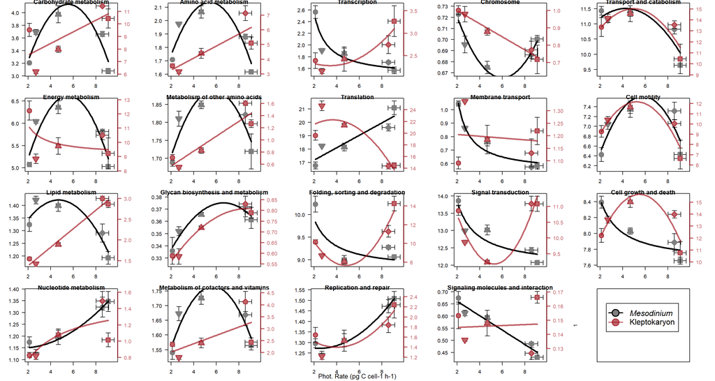

```r
par(mar=c(3,4,0.5,4),mfcol=c(4,5))

subcats <- unique(transcriptprop$desc)

# Photosynthetic rate
for(i in 1:length(subcats)){
  # Summarize the transcriptional data
MCtranscr.summ <- summarySE(data = transcriptprop[transcriptprop$desc==subcats[i] & transcriptprop$org=='MC' & transcriptprop$times!=10,], 'value',groupvars='times')
KNtranscr.summ <- summarySE(data = transcriptprop[transcriptprop$desc==subcats[i] & transcriptprop$org=='KN' & transcriptprop$times!=10,], 'value',groupvars='times')

# MC data
# Plot as a function of photosynthetic rate
plot(PIcell.summ$P_I.cell, MCtranscr.summ$value,las=1,ylab='',xlab='',type='n', xlim =c(min(PIcell.summ$P_I.cell - PIcell.summ$se,na.rm=T),max(PIcell.summ$P_I.cell + PIcell.summ$se,na.rm=T)), ylim = c(min(c(MCtranscr.summ$value-MCtranscr.summ$se),na.rm=T), max(c(MCtranscr.summ$value+MCtranscr.summ$se),na.rm=T)), main = subcats[i])


## Add points
arrows(PIcell.summ$P_I.cell - PIcell.summ$se, MCtranscr.summ$value, PIcell.summ$P_I.cell + PIcell.summ$se, MCtranscr.summ$value, code=3, length= 0.05, angle=90)
arrows(PIcell.summ$P_I.cell, MCtranscr.summ$value - MCtranscr.summ$se, PIcell.summ$P_I.cell, MCtranscr.summ$value + MCtranscr.summ$se, code=3, length= 0.05, angle=90)
points(PIcell.summ$P_I.cell, MCtranscr.summ$value,cex=2,pch=c(21,22,23,24,25),bg='gray50',col='gray50',lwd=2)
#points(PIcell.summ$P_I.cell, MCtranscr.summ$value,cex=2,pch=c(21,22,23,24,25),bg=c(colvec[2:5],colvec[1]),col=c(colvec[2:5],colvec[1]),lwd=2)

## Fit different functions using NLS
dataconcat <- as.data.frame(cbind(PIcell.summ$P_I.cell,MCtranscr.summ$value))
xcoords <- seq(from = min(dataconcat$V1), to = max(dataconcat$V1),length.out = 100)
## Linear model
linmod <- nls(V2 ~ a*V1 + b, data = dataconcat, start = list(a = 0, b = 0))
## Quadratic model
quadmod <- nls(V2 ~ a*(V1 + b)^2 + c, data =dataconcat, start = list(a = 1, b = 0, c= 0))
## Saturating model
satmod <- nls(V2 ~ a*V1 / (b + V1), data = dataconcat, start = list(a = 1, b = 1))

## Choose and plot the best model
AICset <- c(AIC(linmod),AIC(quadmod),AIC(satmod))
if(which(AICset == min(AICset)) == 1){
  lines(xcoords, xcoords*summary(linmod)$parameters[1,1] + summary(linmod)$parameters[2,1], lwd=3, col = 'black')
}
if(which(AICset == min(AICset)) == 2){
  lines(xcoords, summary(quadmod)$parameters[1,1]*(xcoords+summary(quadmod)$parameters[2,1])^2 + summary(quadmod)$parameters[3,1],col='black',lwd=3)
}
if(which(AICset == min(AICset)) == 3){
  lines(xcoords, xcoords*summary(satmod)$parameters[1,1]/(xcoords + summary(satmod)$parameters[2,1]),col='black',lwd=3)
}

# KN data
par(new =TRUE)
plot(PIcell.summ$P_I.cell, MCtranscr.summ$value,las=1,ylab='',xlab='',type='n', xlim =c(min(PIcell.summ$P_I.cell - PIcell.summ$se,na.rm=T),max(PIcell.summ$P_I.cell + PIcell.summ$se,na.rm=T)), ylim = c(min(KNtranscr.summ$value - KNtranscr.summ$se,na.rm=T), max(KNtranscr.summ$value + KNtranscr.summ$se,na.rm=T)), axes = FALSE)
axis(side = 4, col = colvec[3], col.axis = colvec[3], lwd=2,las=1)

## Add points
arrows(PIcell.summ$P_I.cell - PIcell.summ$se, KNtranscr.summ$value, PIcell.summ$P_I.cell + PIcell.summ$se, KNtranscr.summ$value, code=3, length= 0.05, angle=90)
arrows(PIcell.summ$P_I.cell, KNtranscr.summ$value - KNtranscr.summ$se, PIcell.summ$P_I.cell, KNtranscr.summ$value + KNtranscr.summ$se, code=3, length= 0.05, angle=90)
points(PIcell.summ$P_I.cell, KNtranscr.summ$value,cex=2,pch=c(21,22,23,24,25),bg='white',col='white',lwd=2)
points(PIcell.summ$P_I.cell, KNtranscr.summ$value,cex=2,pch=c(21,22,23,24,25),bg=colvec[3],col=colvec[3],lwd=2)

## Fit different functions using NLS
dataconcat <- as.data.frame(cbind(PIcell.summ$P_I.cell,KNtranscr.summ$value))
xcoords <- seq(from = min(dataconcat$V1), to = max(dataconcat$V1),length.out = 100)
## Linear model
linmod <- nls(V2 ~ a*V1 + b, data = dataconcat, start = list(a = 0, b = 0))
## Quadratic model
quadmod <- nls(V2 ~ a*(V1 + b)^2 + c, data =dataconcat, start = list(a = 1, b = 0, c= 0))
## Saturating model
satmod <- nls(V2 ~ a*V1 / (b + V1), data = dataconcat, start = list(a = 1, b = 0))

## Choose and plot the best model
AICset <- c(AIC(linmod),AIC(quadmod),AIC(satmod))
if(which(AICset == min(AICset)) == 1){
  lines(xcoords, xcoords*summary(linmod)$parameters[1,1] + summary(linmod)$parameters[2,1], lwd=3, col = colvec[3])
}
if(which(AICset == min(AICset)) == 2){
  lines(xcoords, summary(quadmod)$parameters[1,1]*(xcoords+summary(quadmod)$parameters[2,1])^2 + summary(quadmod)$parameters[3,1],col=colvec[3],lwd=3)
}
if(which(AICset == min(AICset)) == 3){
  lines(xcoords, xcoords*summary(satmod)$parameters[1,1]/(xcoords + summary(satmod)$parameters[2,1]),col=colvec[3],lwd=3)
}


if(i == 12){
  mtext(paste('Phot. Rate (pg C cell-1 h-1)'),side=1,line=1.8,cex=.8)
}
}
plot(1,1,type='n',xaxt='n',yaxt='n')
legend(x='topleft',inset=c(.1,.2),legend=c(expression(italic('Mesodinium')),'Kleptokaryon'),pch=c(21,21),pt.cex=3,lwd=2, col=c('black',colvec[3]), pt.bg=c('gray50',colvec[3]),lty=c(1,1),cex=1.5)
```

Growth rates –

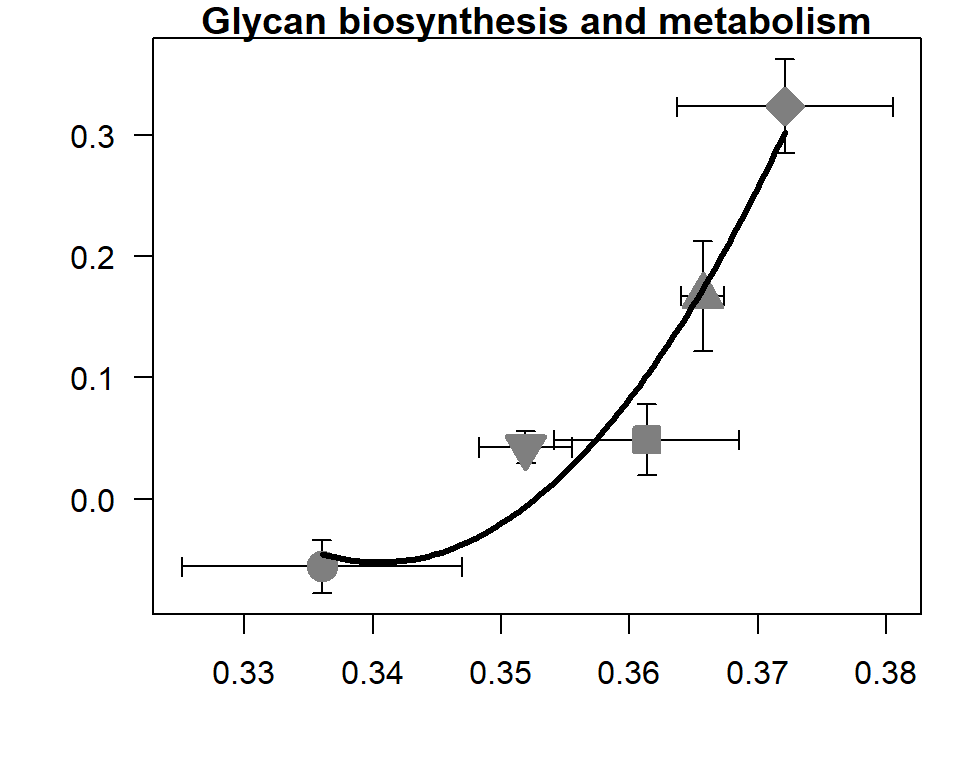

```r
i <- 7

MCtranscr.summ <- summarySE(data = transcriptprop[transcriptprop$desc==subcats[i] & transcriptprop$org=='MC' & transcriptprop$times!=10,], 'value',groupvars='times')
KNtranscr.summ <- summarySE(data = transcriptprop[transcriptprop$desc==subcats[i] & transcriptprop$org=='KN' & transcriptprop$times!=10,], 'value',groupvars='times')


par(mar=c(4,4,1,1))


# MC data
# Plot as a function of growth rate
plot(mu.summ$mu ~ MCtranscr.summ$value,las=1,ylab='',xlab='',type='n', ylim =c(min(mu.summ$mu - mu.summ$se,na.rm=T),max(mu.summ$mu + mu.summ$se,na.rm=T)), xlim = c(min(c(MCtranscr.summ$value-MCtranscr.summ$se),na.rm=T), max(c(MCtranscr.summ$value+MCtranscr.summ$se),na.rm=T)), main = subcats[i])


## Add points
arrows(MCtranscr.summ$value, mu.summ$mu - mu.summ$se, MCtranscr.summ$value, mu.summ$mu + mu.summ$se, code=3, length= 0.05, angle=90)
arrows(MCtranscr.summ$value - MCtranscr.summ$se, mu.summ$mu, MCtranscr.summ$value + MCtranscr.summ$se, mu.summ$mu, code=3, length= 0.05, angle=90)
points(mu.summ$mu ~ MCtranscr.summ$value,cex=2,pch=c(21,22,23,24,25),bg='gray50',col='gray50',lwd=2)

## Fit different functions using NLS
dataconcat <- as.data.frame(cbind(MCtranscr.summ$value,mu.summ$mu))
xcoords <- seq(from = min(dataconcat$V1), to = max(dataconcat$V1),length.out = 100)
## Linear model
linmod <- nls(V2 ~ a*V1 + b, data = dataconcat, start = list(a = 0, b = 0))
## Quadratic model
quadmod <- nls(V2 ~ a*(V1 + b)^2 + c, data =dataconcat, start = list(a = 1, b = -mean(dataconcat$V1,na.rm=T), c = .0))
## Saturating model
#satmod <- nls(V2 ~ a*V1 / (b + V1) + c, data = dataconcat, start = list(a = .1, b = 1, c = 0))

## Choose and plot the best model
#AICset <- c(AIC(linmod),AIC(quadmod),AIC(satmod))
AICset <- c(AIC(linmod),AIC(quadmod))
if(which(AICset == min(AICset)) == 1){
  lines(xcoords, xcoords*summary(linmod)$parameters[1,1] + summary(linmod)$parameters[2,1], lwd=3, col = 'black')
}
if(which(AICset == min(AICset)) == 2){
  lines(xcoords, summary(quadmod)$parameters[1,1]*(xcoords+summary(quadmod)$parameters[2,1])^2 + summary(quadmod)$parameters[3,1],col='black',lwd=3)
}
```

```r
#if(which(AICset == min(AICset)) == 3){
#  lines(xcoords, xcoords*summary(satmod)$parameters[1,1]/(xcoords + #summary(satmod)$parameters[2,1]),col='black',lwd=3)
#}
```

Iterate through all categories and plot only the best-fitting model

```r
svg("output/fractions_v_growth.svg", height = 9, width = 14)

par(mar=c(3,4,0.5,0),mfcol=c(4,5))

R2.threshold <- 0.5

subcats <- unique(transcriptprop$desc)

# Photosynthetic rate
for(i in 1:length(subcats)){
  # Summarize the transcriptional data
MCtranscr.summ <- summarySE(data = transcriptprop[transcriptprop$desc==subcats[i] & transcriptprop$org=='MC' & transcriptprop$times!=10,], 'value',groupvars='times')
KNtranscr.summ <- summarySE(data = transcriptprop[transcriptprop$desc==subcats[i] & transcriptprop$org=='KN' & transcriptprop$times!=10,], 'value',groupvars='times')

  # Plot as a function of photosynthetic rate
  plot(mu.summ$mu, MCtranscr.summ$value,las=1,ylab='',xlab='',type='n', xlim =c(min(mu.summ$mu - mu.summ$se,na.rm=T),max(mu.summ$mu + mu.summ$se,na.rm=T)), ylim = c(min(c(MCtranscr.summ$value-MCtranscr.summ$se, KNtranscr.summ$value - KNtranscr.summ$se),na.rm=T), max(c(MCtranscr.summ$value+MCtranscr.summ$se, KNtranscr.summ$value + KNtranscr.summ$se),na.rm=T)), main = subcats[i])

# MC data
## Add points
arrows(mu.summ$mu - mu.summ$se, MCtranscr.summ$value, mu.summ$mu + mu.summ$se, MCtranscr.summ$value, code=3, length= 0.05, angle=90)
arrows(mu.summ$mu, MCtranscr.summ$value - MCtranscr.summ$se, mu.summ$mu, MCtranscr.summ$value + MCtranscr.summ$se, code=3, length= 0.05, angle=90)
points(mu.summ$mu, MCtranscr.summ$value,cex=2,pch=c(21,22,23,24,25),bg='gray50',col='gray50',lwd=2)
#points(mu.summ$mu, MCtranscr.summ$value,cex=2,pch=c(21,22,23,24,25),bg=c(colvec[2:5],colvec[1]),col=c(colvec[2:5],colvec[1]),lwd=2)

## Fit different functions using NLS
dataconcat <- as.data.frame(cbind(mu.summ$mu,MCtranscr.summ$value))
xcoords <- seq(from = min(dataconcat$V1), to = max(dataconcat$V1),length.out = 100)
## Linear model
linmod <- nls(V2 ~ a*V1 + b, data = dataconcat, start = list(a = 0, b = 0))
## Quadratic model
quadmod <- nls(V2 ~ a*(V1 + b)^2 + c, data =dataconcat, start = list(a = 1, b = 0, c= 0))
## Saturating model
#satmod <- nls(V2 ~ a*V1 / (b + V1) + c, data = dataconcat, start = list(a = 1, b = 1, c = 0))

## Choose and plot the best model
V2bar <- mean(dataconcat$V2,na.rm=T)
SStot <- sum((dataconcat$V2 - V2bar)^2)
AICset <- c(AIC(linmod),AIC(quadmod))#,AIC(satmod))
if(which(AICset == min(AICset)) == 1){
  SSres <- sum((summary(linmod)$residuals)^2)
  pseudo.R2 <- 1 - SSres/SStot
  if(pseudo.R2 > R2.threshold){
    lines(xcoords, xcoords*summary(linmod)$parameters[1,1] + summary(linmod)$parameters[2,1], lwd=3, col = 'black')
  }
}
if(which(AICset == min(AICset)) == 2){
  SSres <- sum((summary(quadmod)$residuals)^2)
  pseudo.R2 <- 1 - SSres/SStot
  if(pseudo.R2 > R2.threshold){
    lines(xcoords, summary(quadmod)$parameters[1,1]*(xcoords+summary(quadmod)$parameters[2,1])^2 + summary(quadmod)$parameters[3,1],col='black',lwd=3)
  }
}
if(which(AICset == min(AICset)) == 3){
  SSres <- sum((summary(satmod)$residuals)^2)
  pseudo.R2 <- 1 - SSres/SStot
  if(pseudo.R2 > R2.threshold){
    lines(xcoords, xcoords*summary(satmod)$parameters[1,1]/(xcoords + summary(satmod)$parameters[2,1]),col='black',lwd=3)
  }
}

# KN data
## Add points
arrows(mu.summ$mu - mu.summ$se, KNtranscr.summ$value, mu.summ$mu + mu.summ$se, KNtranscr.summ$value, code=3, length= 0.05, angle=90)
arrows(mu.summ$mu, KNtranscr.summ$value - KNtranscr.summ$se, mu.summ$mu, KNtranscr.summ$value + KNtranscr.summ$se, code=3, length= 0.05, angle=90)
points(mu.summ$mu, KNtranscr.summ$value,cex=2,pch=c(21,22,23,24,25),bg='white',col='white',lwd=2)
points(mu.summ$mu, KNtranscr.summ$value,cex=2,pch=c(21,22,23,24,25),bg=colvec[3],col=colvec[3],lwd=2)

## Fit different functions using NLS
dataconcat <- as.data.frame(cbind(mu.summ$mu,KNtranscr.summ$value))
xcoords <- seq(from = min(dataconcat$V1), to = max(dataconcat$V1),length.out = 100)
## Linear model
linmod <- nls(V2 ~ a*V1 + b, data = dataconcat, start = list(a = 0, b = 0))
## Quadratic model
quadmod <- nls(V2 ~ a*(V1 + b)^2 + c, data =dataconcat, start = list(a = 1, b = 0, c= 0))
## Saturating model
#satmod <- nls(V2 ~ a*V1 / (b + V1) + c, data = dataconcat, start = list(a = 1, b = 0, c = -.10))

## Choose and plot the best model
V2bar <- mean(dataconcat$V2,na.rm=T)
SStot <- sum((dataconcat$V2 - V2bar)^2)
AICset <- c(AIC(linmod),AIC(quadmod))#,AIC(satmod))
if(which(AICset == min(AICset)) == 1){
  SSres <- sum((summary(linmod)$residuals)^2)
  pseudo.R2 <- 1 - SSres/SStot
  if(pseudo.R2 > R2.threshold){
    lines(xcoords, xcoords*summary(linmod)$parameters[1,1] + summary(linmod)$parameters[2,1], lwd=3, col = colvec[3])
  }
}
if(which(AICset == min(AICset)) == 2){
  SSres <- sum((summary(quadmod)$residuals)^2)
  pseudo.R2 <- 1 - SSres/SStot
  if(pseudo.R2 > R2.threshold){
    lines(xcoords, summary(quadmod)$parameters[1,1]*(xcoords+summary(quadmod)$parameters[2,1])^2 + summary(quadmod)$parameters[3,1],col=colvec[3],lwd=3)
  }
}
if(which(AICset == min(AICset)) == 3){
  SSres <- sum((summary(satmod)$residuals)^2)
  pseudo.R2 <- 1 - SSres/SStot
  if(pseudo.R2 > R2.threshold){
    lines(xcoords, xcoords*summary(satmod)$parameters[1,1]/(xcoords + summary(satmod)$parameters[2,1]) + summary(satmod)$parameters[3,1],col=colvec[3],lwd=3)
  }
}


if(i == 12){
  mtext(paste('Growth rate (d-1)'),side=1,line=1.8,cex=.8)
}
}
plot(1,1,type='n',xaxt='n',yaxt='n')
legend(x='topleft',inset=c(.1,.2),legend=c(expression(italic('Mesodinium')),'Kleptokaryon'),pch=c(21,21),pt.cex=3,lwd=2, col=c('black',colvec[3]), pt.bg=c('gray50',colvec[3]),lty=c(1,1),cex=1.5)

dev.off()
```

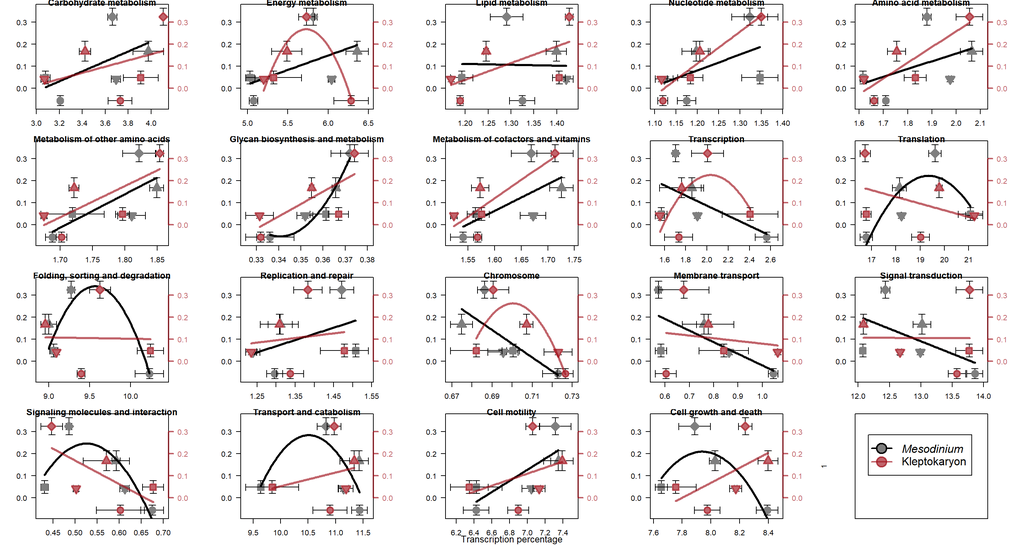

```r
par(mar=c(3,4,0.5,4),mfrow=c(4,5))

subcats <- unique(transcriptprop$desc)

# Growth rate
for(i in 1:length(subcats)){
  # Summarize the transcriptional data
MCtranscr.summ <- summarySE(data = transcriptprop[transcriptprop$desc==subcats[i] & transcriptprop$org=='MC' & transcriptprop$times!=10,], 'value',groupvars='times')
KNtranscr.summ <- summarySE(data = transcriptprop[transcriptprop$desc==subcats[i] & transcriptprop$org=='KN' & transcriptprop$times!=10,], 'value',groupvars='times')

# MC data
# Plot as a function of photosynthetic rate
plot(mu.summ$mu ~ MCtranscr.summ$value,las=1,ylab='',xlab='',type='n', ylim =c(min(mu.summ$mu - mu.summ$se,na.rm=T),max(mu.summ$mu + mu.summ$se,na.rm=T)), xlim = c(min(c(MCtranscr.summ$value-MCtranscr.summ$se),na.rm=T), max(c(MCtranscr.summ$value+MCtranscr.summ$se),na.rm=T)), main = subcats[i])


## Add points
arrows(MCtranscr.summ$value, mu.summ$mu - mu.summ$se, MCtranscr.summ$value, mu.summ$mu + mu.summ$se, code=3, length= 0.05, angle=90)
arrows(MCtranscr.summ$value - MCtranscr.summ$se, mu.summ$mu, MCtranscr.summ$value + MCtranscr.summ$se, mu.summ$mu, code=3, length= 0.05, angle=90)
points(mu.summ$mu ~ MCtranscr.summ$value,cex=2,pch=c(21,22,23,24,25),bg='gray50',col='gray50',lwd=2)

## Fit different functions using NLS
dataconcat <- as.data.frame(cbind(MCtranscr.summ$value,mu.summ$mu))
xcoords <- seq(from = min(dataconcat$V1), to = max(dataconcat$V1),length.out = 100)
## Linear model
linmod <- nls(V2 ~ a*V1 + b, data = dataconcat, start = list(a = 0, b = 0))
## Quadratic model
quadmod <- nls(V2 ~ a*(V1 + b)^2 + c, data =dataconcat, start = list(a = -1, b = -mean(dataconcat$V1,na.rm=T), c = .0))
## Saturating model
#satmod <- nls(V2 ~ a*V1 / (b + V1), data = dataconcat, start = list(a = 10, b = 3))

## Choose and plot the best model
#AICset <- c(AIC(linmod),AIC(quadmod),AIC(satmod))
AICset <- c(AIC(linmod),AIC(quadmod))
if(which(AICset == min(AICset)) == 1){
  lines(xcoords, xcoords*summary(linmod)$parameters[1,1] + summary(linmod)$parameters[2,1], lwd=3, col = 'black')
}
if(which(AICset == min(AICset)) == 2){
  lines(xcoords, summary(quadmod)$parameters[1,1]*(xcoords+summary(quadmod)$parameters[2,1])^2 + summary(quadmod)$parameters[3,1],col='black',lwd=3)
}
#if(which(AICset == min(AICset)) == 3){
#  lines(xcoords, xcoords*summary(satmod)$parameters[1,1]/(xcoords + #summary(satmod)$parameters[2,1]),col='black',lwd=3)
#}

# KN data
par(new =TRUE)
plot(mu.summ$mu ~ MCtranscr.summ$value,las=1,ylab='',xlab='',type='n', ylim =c(min(mu.summ$mu - mu.summ$se,na.rm=T),max(mu.summ$mu + mu.summ$se,na.rm=T)), xlim = c(min(KNtranscr.summ$value - KNtranscr.summ$se,na.rm=T), max(KNtranscr.summ$value + KNtranscr.summ$se,na.rm=T)), axes = FALSE)
axis(side = 4, col = colvec[3], col.axis = colvec[3], lwd=2,las=1)

## Add points
arrows(KNtranscr.summ$value, mu.summ$mu - mu.summ$se, KNtranscr.summ$value, mu.summ$mu + mu.summ$se, code=3, length= 0.05, angle=90)
arrows(KNtranscr.summ$value - KNtranscr.summ$se, mu.summ$mu, KNtranscr.summ$value + KNtranscr.summ$se, mu.summ$mu, code=3, length= 0.05, angle=90)
points(mu.summ$mu ~ KNtranscr.summ$value,cex=2,pch=c(21,22,23,24,25),bg='white',col='white',lwd=2)
points(mu.summ$mu ~ KNtranscr.summ$value,cex=2,pch=c(21,22,23,24,25),bg=colvec[3],col=colvec[3],lwd=2)

## Fit different functions using NLS
dataconcat <- as.data.frame(cbind(KNtranscr.summ$value,mu.summ$mu))
xcoords <- seq(from = min(dataconcat$V1), to = max(dataconcat$V1),length.out = 100)
## Linear model
linmod <- nls(V2 ~ a*V1 + b, data = dataconcat, start = list(a = 0, b = 0))
## Quadratic model
quadmod <- nls(V2 ~ a*(V1 + b)^2 + c, data =dataconcat, start = list(a = -1, b = -mean(dataconcat$V1,na.rm=T), c= 0))
## Saturating model
#satmod <- nls(V2 ~ a*V1 / (b + V1), data = dataconcat, start = list(a = 1, b = 1))

## Choose and plot the best model
#AICset <- c(AIC(linmod),AIC(quadmod),AIC(satmod))
AICset <- c(AIC(linmod),AIC(quadmod))
if(which(AICset == min(AICset)) == 1){
  lines(xcoords, xcoords*summary(linmod)$parameters[1,1] + summary(linmod)$parameters[2,1], lwd=3, col = colvec[3])
}
if(which(AICset == min(AICset)) == 2){
  lines(xcoords, summary(quadmod)$parameters[1,1]*(xcoords+summary(quadmod)$parameters[2,1])^2 + summary(quadmod)$parameters[3,1],col=colvec[3],lwd=3)
}
#if(which(AICset == min(AICset)) == 3){
#  lines(xcoords, xcoords*summary(satmod)$parameters[1,1]/(xcoords + #summary(satmod)$parameters[2,1]),col=colvec[3],lwd=3)
#}


if(i == 18){
  mtext(paste('Transcription percentage'),side=1,line=1.8,cex=.8)
}
}
plot(1,1,type='n',xaxt='n',yaxt='n')
legend(x='topleft',inset=c(.1,.2),legend=c(expression(italic('Mesodinium')),'Kleptokaryon'),pch=c(21,21),pt.cex=3,lwd=2, col=c('black',colvec[3]), pt.bg=c('gray50',colvec[3]),lty=c(1,1),cex=1.5)
```

# Export data

```r
write.csv(dat2, "output/physiology-all.csv")
write.csv(subdat, "output/physiology-paired.csv")
```